# A study of an Educational Process Mining (EPM): A Learning Analytics Data Set

Faye Zhang

**Hello all,**  
I studied a data set that focused on Educational Process Mining (EPM) and provided A Learning Analytics Data Set provided by *Smartlab* and the *Department of Industrial Design, The Netherlands.*

License:  
*[1] M. Vahdat, L. Oneto, D. Anguita, M. Funk, M. Rauterberg.: A learning analytics approach to correlate the academic achievements of students with interaction data from an educational simulator. In: G. Conole et al. (eds.): EC-TEL 2015, LNCS 9307, pp. 352-366. Springer (2015).* *DOI: 10.1007/978-3-319-24258-3 26*

# What is this Data Set and Where did I Find it?

The data set I worked with was one created from an experiement carried out with a **group of 115 students** of **first year undergraduate Engineering major** of the University of Genoa.

I stumbled upon this data set whist looking for a data set that explored academics. While I did find other data that may have come cleaner thank this set, I settled on working on this set because of the *nature* of this study.

I dove deep into this pack of findings and looked for correlations in the information that had been collected.

```r
getwd()
setwd("C:/Users/fzhang/OneDrive - Eastside Preparatory School/Attachments/Grade 10/Winter Tri/Data Science/EPM Dataset 2/Data/")
```

My hypothesis was that:

## *The more time spent on the lessons by students will directly correlate to a higher test score.*

# How did I clean the data set?

The data I found and worked with was not *clean* nor *nice*. It was sent into my download folder as a .torrent file which I converted to a .zip file with much difficulty.

Not only was the data set sent in an sealed folder, the data was organized in a way that it was all spread out in a mass of different files. In order to clean and condense all of the data provided by the study, I needed to read every file in and pick out the neccesary information to condense into **one** data frame.

Due to the restriction of time, I decided to use only the data collected from one session: **Session 4** and use the scores from the intermediate grades as they provided a complete set of grades.

The following chunck shows the reading of **99** data sets of **Session 4**.

```r
#getting directory
getwd()

# setting directory
setwd("C:/Users/fzhang/OneDrive - Eastside Preparatory School/Attachments/Grade 10/Winter Tri/Data Science/EPM Dataset 2/Data/")

# reading all data sets
X1 <- read.csv("Processes/Session 4/1")
X2 <- read.csv("Processes/Session 4/2")
X3 <- read.csv("Processes/Session 4/3")
X4 <- read.csv("Processes/Session 4/4")
X5 <- read.csv("Processes/Session 4/5")
X6 <- read.csv("Processes/Session 4/6")
X7 <- read.csv("Processes/Session 4/7")
X8 <- read.csv("Processes/Session 4/8")
X9 <- read.csv("Processes/Session 4/9")
X10 <- read.csv("Processes/Session 4/10")
X11 <- read.csv("Processes/Session 4/11")
X12 <- read.csv("Processes/Session 4/12")
X13 <- read.csv("Processes/Session 4/13")
X14 <- read.csv("Processes/Session 4/14")
X15 <- read.csv("Processes/Session 4/15")
X16 <- read.csv("Processes/Session 4/16")
X17 <- read.csv("Processes/Session 4/17")
X18 <- read.csv("Processes/Session 4/18")
X19 <- read.csv("Processes/Session 4/19")
X20 <- read.csv("Processes/Session 4/20")
X21 <- read.csv("Processes/Session 4/21")
X22 <- read.csv("Processes/Session 4/22")
X23 <- read.csv("Processes/Session 4/23")
X24 <- read.csv("Processes/Session 4/24")
X25 <- read.csv("Processes/Session 4/25")
X26 <- read.csv("Processes/Session 4/26")
X27 <- read.csv("Processes/Session 4/27")
X28 <- read.csv("Processes/Session 4/28")
X29 <- read.csv("Processes/Session 4/29")
X30 <- read.csv("Processes/Session 4/30")
X31 <- read.csv("Processes/Session 4/31")
X32 <- read.csv("Processes/Session 4/32")
X33 <- read.csv("Processes/Session 4/33")
X34 <- read.csv("Processes/Session 4/34")
X35 <- read.csv("Processes/Session 4/35")
X36 <- read.csv("Processes/Session 4/36")
X37 <- read.csv("Processes/Session 4/37")
X38 <- read.csv("Processes/Session 4/38")
X39 <- read.csv("Processes/Session 4/39")
X40 <- read.csv("Processes/Session 4/40")
X41 <- read.csv("Processes/Session 4/41")
X42 <- read.csv("Processes/Session 4/42")
X43 <- read.csv("Processes/Session 4/43")
X44 <- read.csv("Processes/Session 4/44")
X45 <- read.csv("Processes/Session 4/45")
X46 <- read.csv("Processes/Session 4/46")
X47 <- read.csv("Processes/Session 4/47")
X48 <- read.csv("Processes/Session 4/48")
X49 <- read.csv("Processes/Session 4/49")
X50 <- read.csv("Processes/Session 4/50")
X51 <- read.csv("Processes/Session 4/51")
X52 <- read.csv("Processes/Session 4/52")
X53 <- read.csv("Processes/Session 4/53")
X54 <- read.csv("Processes/Session 4/54")
X55 <- read.csv("Processes/Session 4/55")
X56 <- read.csv("Processes/Session 4/56")
X57 <- read.csv("Processes/Session 4/57")
X58 <- read.csv("Processes/Session 4/58")
X59 <- read.csv("Processes/Session 4/59")
X60 <- read.csv("Processes/Session 4/60")
X61 <- read.csv("Processes/Session 4/61")
X62 <- read.csv("Processes/Session 4/62")
X63 <- read.csv("Processes/Session 4/63")
X64 <- read.csv("Processes/Session 4/64")
X65 <- read.csv("Processes/Session 4/65")
X66 <- read.csv("Processes/Session 4/66")
X67 <- read.csv("Processes/Session 4/67")
X68 <- read.csv("Processes/Session 4/68")
X69 <- read.csv("Processes/Session 4/69")
X70 <- read.csv("Processes/Session 4/70")
X71 <- read.csv("Processes/Session 4/71")
X72 <- read.csv("Processes/Session 4/72")
X73 <- read.csv("Processes/Session 4/73")
X74 <- read.csv("Processes/Session 4/74")
X75 <- read.csv("Processes/Session 4/75")
X76 <- read.csv("Processes/Session 4/76")
X77 <- read.csv("Processes/Session 4/77")
X78 <- read.csv("Processes/Session 4/78")
X79 <- read.csv("Processes/Session 4/79")
X80 <- read.csv("Processes/Session 4/80")
X81 <- read.csv("Processes/Session 4/81")
X82 <- read.csv("Processes/Session 4/82")
X83 <- read.csv("Processes/Session 4/83")
X84 <- read.csv("Processes/Session 4/84")
X85 <- read.csv("Processes/Session 4/85")
X86 <- read.csv("Processes/Session 4/86")
X87 <- read.csv("Processes/Session 4/87")
X88 <- read.csv("Processes/Session 4/88")
X89 <- read.csv("Processes/Session 4/89")
X90 <- read.csv("Processes/Session 4/90")
X91 <- read.csv("Processes/Session 4/91")
X92 <- read.csv("Processes/Session 4/92")
X93 <- read.csv("Processes/Session 4/93")
X94 <- read.csv("Processes/Session 4/94")
X95 <- read.csv("Processes/Session 4/95")
X96 <- read.csv("Processes/Session 4/96")
X97 <- read.csv("Processes/Session 4/97")
X98 <- read.csv("Processes/Session 4/98")
X99 <- read.csv("Processes/Session 4/99")

#reading excel files from : https://www.datacamp.com/community/tutorials/linear-regression-R
library(readxl)
finalScore <- read_excel("final_grades.xlsx")
midScore <- read_excel("intermediate_grades.xlsx")
```

After reading all of the data sets into the program, I needed **select** and then **combine** all the choosen data into one data set.

In each process file, data was provided on:  
**1** session  
**2** student_Id  
**3** exercise  
**4** activity  
**5** start_time  
**6** end_time  
**7** idle_time  
**8** mouse_wheel  
**9** mouse_wheel_click  
**10** mouse_click_left  
**11** mouse_click_right  
**12** mouse_movement  
**13** keystroke

The following chunck shows how I created the *vast* data set.

```r
#combinging all data
temp <- X1
# time difference from: https://stackoverflow.com/questions/26342473/subtract-time-in-r#26343022
# more time difference from:  https://stackoverflow.com/questions/9372521/subtracting-two-columns-consisting-of-both-date-and-time-in-r
temp$start_time <- as.POSIXct(temp$start_time,
                            format='%d.%m.%Y %H:%M:%S')
temp$end_time <- as.POSIXct(temp$end_time,
                          format='%d.%m.%Y %H:%M:%S')
temp$start_time<-as.numeric(temp$start_time)
temp$end_time<-as.numeric(temp$end_time)
temp$total_time<-temp$end_time-temp$start_time
# creating combined data set
# solving atomic vectors error:
#     https://arrgh.tim-smith.us/atomic.html
#     Also solved by refreshing the above chunk
student_Id <- temp$student_Id[1]
combined <- data.frame(student_Id)
combined$total_time <- sum(temp$total_time)
combined$mouse_movement <- sum(temp$mouse_movement)
combined$mouse_click_left <- sum(temp$mouse_click_left)
combined$mouse_click_right <- sum(temp$mouse_click_right)
combined$midScore <- midScore$`Session 4`[temp$student_Id[1]]
temp <- X2
temp$start_time <- as.POSIXct(temp$start_time,
                            format='%d.%m.%Y %H:%M:%S')
temp$end_time <- as.POSIXct(temp$end_time,
                          format='%d.%m.%Y %H:%M:%S')
temp$start_time<-as.numeric(temp$start_time)
temp$end_time<-as.numeric(temp$end_time)
temp$total_time<-temp$end_time-temp$start_time
student_Id <- temp$student_Id[1]
temp2 <- data.frame(student_Id)
temp2$total_time <- sum(temp$total_time)
temp2$mouse_movement <- sum(temp$mouse_movement)
temp2$mouse_click_left <- sum(temp$mouse_click_left)
temp2$mouse_click_right <- sum(temp$mouse_click_right)
temp2$midScore <- midScore$`Session 4`[temp$student_Id[1]]
# rbind info from: https://stackoverflow.com/questions/28467068/add-row-to-dataframe#28468977
combined <- rbind(combined, temp2)
temp <- X3
temp$start_time <- as.POSIXct(temp$start_time,
                            format='%d.%m.%Y %H:%M:%S')
temp$end_time <- as.POSIXct(temp$end_time,
                          format='%d.%m.%Y %H:%M:%S')
temp$start_time<-as.numeric(temp$start_time)
temp$end_time<-as.numeric(temp$end_time)
temp$total_time<-temp$end_time-temp$start_time
student_Id <- temp$student_Id[1]
temp2 <- data.frame(student_Id)
temp2$total_time <- sum(temp$total_time)
temp2$mouse_movement <- sum(temp$mouse_movement)
temp2$mouse_click_left <- sum(temp$mouse_click_left)
temp2$mouse_click_right <- sum(temp$mouse_click_right)
temp2$midScore <- midScore$`Session 4`[temp$student_Id[1]]
combined <- rbind(combined, temp2)
temp <- X4
temp$start_time <- as.POSIXct(temp$start_time,
                            format='%d.%m.%Y %H:%M:%S')
temp$end_time <- as.POSIXct(temp$end_time,
                          format='%d.%m.%Y %H:%M:%S')
temp$start_time<-as.numeric(temp$start_time)
temp$end_time<-as.numeric(temp$end_time)
temp$total_time<-temp$end_time-temp$start_time
student_Id <- temp$student_Id[1]
temp2 <- data.frame(student_Id)
temp2$total_time <- sum(temp$total_time)
temp2$mouse_movement <- sum(temp$mouse_movement)
temp2$mouse_click_left <- sum(temp$mouse_click_left)
temp2$mouse_click_right <- sum(temp$mouse_click_right)
temp2$midScore <- midScore$`Session 4`[temp$student_Id[1]]
combined <- rbind(combined, temp2)
temp <- X5
temp$start_time <- as.POSIXct(temp$start_time,
                            format='%d.%m.%Y %H:%M:%S')
temp$end_time <- as.POSIXct(temp$end_time,
                          format='%d.%m.%Y %H:%M:%S')
temp$start_time<-as.numeric(temp$start_time)
temp$end_time<-as.numeric(temp$end_time)
temp$total_time<-temp$end_time-temp$start_time
student_Id <- temp$student_Id[1]
temp2 <- data.frame(student_Id)
temp2$total_time <- sum(temp$total_time)
temp2$mouse_movement <- sum(temp$mouse_movement)
temp2$mouse_click_left <- sum(temp$mouse_click_left)
temp2$mouse_click_right <- sum(temp$mouse_click_right)
temp2$midScore <- midScore$`Session 4`[temp$student_Id[1]]
combined <- rbind(combined, temp2)
temp <- X6
temp$start_time <- as.POSIXct(temp$start_time,
                            format='%d.%m.%Y %H:%M:%S')
temp$end_time <- as.POSIXct(temp$end_time,
                          format='%d.%m.%Y %H:%M:%S')
temp$start_time<-as.numeric(temp$start_time)
temp$end_time<-as.numeric(temp$end_time)
temp$total_time<-temp$end_time-temp$start_time
student_Id <- temp$student_Id[1]
temp2 <- data.frame(student_Id)
temp2$total_time <- sum(temp$total_time)
temp2$mouse_movement <- sum(temp$mouse_movement)
temp2$mouse_click_left <- sum(temp$mouse_click_left)
temp2$mouse_click_right <- sum(temp$mouse_click_right)
temp2$midScore <- midScore$`Session 4`[temp$student_Id[1]]
combined <- rbind(combined, temp2)
temp <- X7
temp$start_time <- as.POSIXct(temp$start_time,
                            format='%d.%m.%Y %H:%M:%S')
temp$end_time <- as.POSIXct(temp$end_time,
                          format='%d.%m.%Y %H:%M:%S')
temp$start_time<-as.numeric(temp$start_time)
temp$end_time<-as.numeric(temp$end_time)
temp$total_time<-temp$end_time-temp$start_time
student_Id <- temp$student_Id[1]
temp2 <- data.frame(student_Id)
temp2$total_time <- sum(temp$total_time)
temp2$mouse_movement <- sum(temp$mouse_movement)
temp2$mouse_click_left <- sum(temp$mouse_click_left)
temp2$mouse_click_right <- sum(temp$mouse_click_right)
temp2$midScore <- midScore$`Session 4`[temp$student_Id[1]]
combined <- rbind(combined, temp2)
temp <- X8
temp$start_time <- as.POSIXct(temp$start_time,
                            format='%d.%m.%Y %H:%M:%S')
temp$end_time <- as.POSIXct(temp$end_time,
                          format='%d.%m.%Y %H:%M:%S')
temp$start_time<-as.numeric(temp$start_time)
temp$end_time<-as.numeric(temp$end_time)
temp$total_time<-temp$end_time-temp$start_time
student_Id <- temp$student_Id[1]
temp2 <- data.frame(student_Id)
temp2$total_time <- sum(temp$total_time)
temp2$mouse_movement <- sum(temp$mouse_movement)
temp2$mouse_click_left <- sum(temp$mouse_click_left)
temp2$mouse_click_right <- sum(temp$mouse_click_right)
temp2$midScore <- midScore$`Session 4`[temp$student_Id[1]]
combined <- rbind(combined, temp2)
temp <- X9
temp$start_time <- as.POSIXct(temp$start_time,
                            format='%d.%m.%Y %H:%M:%S')
temp$end_time <- as.POSIXct(temp$end_time,
                          format='%d.%m.%Y %H:%M:%S')
temp$start_time<-as.numeric(temp$start_time)
temp$end_time<-as.numeric(temp$end_time)
temp$total_time<-temp$end_time-temp$start_time
student_Id <- temp$student_Id[1]
temp2 <- data.frame(student_Id)
temp2$total_time <- sum(temp$total_time)
temp2$mouse_movement <- sum(temp$mouse_movement)
temp2$mouse_click_left <- sum(temp$mouse_click_left)
temp2$mouse_click_right <- sum(temp$mouse_click_right)
temp2$midScore <- midScore$`Session 4`[temp$student_Id[1]]
combined <- rbind(combined, temp2)
temp <- X10
temp$start_time <- as.POSIXct(temp$start_time,
                            format='%d.%m.%Y %H:%M:%S')
temp$end_time <- as.POSIXct(temp$end_time,
                          format='%d.%m.%Y %H:%M:%S')
temp$start_time<-as.numeric(temp$start_time)
temp$end_time<-as.numeric(temp$end_time)
temp$total_time<-temp$end_time-temp$start_time
student_Id <- temp$student_Id[1]
temp2 <- data.frame(student_Id)
temp2$total_time <- sum(temp$total_time)
temp2$mouse_movement <- sum(temp$mouse_movement)
temp2$mouse_click_left <- sum(temp$mouse_click_left)
temp2$mouse_click_right <- sum(temp$mouse_click_right)
temp2$midScore <- midScore$`Session 4`[temp$student_Id[1]]
combined <- rbind(combined, temp2)
temp <- X11
temp$start_time <- as.POSIXct(temp$start_time,
                            format='%d.%m.%Y %H:%M:%S')
temp$end_time <- as.POSIXct(temp$end_time,
                          format='%d.%m.%Y %H:%M:%S')
temp$start_time<-as.numeric(temp$start_time)
temp$end_time<-as.numeric(temp$end_time)
temp$total_time<-temp$end_time-temp$start_time
student_Id <- temp$student_Id[1]
temp2 <- data.frame(student_Id)
temp2$total_time <- sum(temp$total_time)
temp2$mouse_movement <- sum(temp$mouse_movement)
temp2$mouse_click_left <- sum(temp$mouse_click_left)
temp2$mouse_click_right <- sum(temp$mouse_click_right)
temp2$midScore <- midScore$`Session 4`[temp$student_Id[1]]
combined <- rbind(combined, temp2)
temp <- X12
temp$start_time <- as.POSIXct(temp$start_time,
                            format='%d.%m.%Y %H:%M:%S')
temp$end_time <- as.POSIXct(temp$end_time,
                          format='%d.%m.%Y %H:%M:%S')
temp$start_time<-as.numeric(temp$start_time)
temp$end_time<-as.numeric(temp$end_time)
temp$total_time<-temp$end_time-temp$start_time
student_Id <- temp$student_Id[1]
temp2 <- data.frame(student_Id)
temp2$total_time <- sum(temp$total_time)
temp2$mouse_movement <- sum(temp$mouse_movement)
temp2$mouse_click_left <- sum(temp$mouse_click_left)
temp2$mouse_click_right <- sum(temp$mouse_click_right)
temp2$midScore <- midScore$`Session 4`[temp$student_Id[1]]
combined <- rbind(combined, temp2)
temp <- X13
temp$start_time <- as.POSIXct(temp$start_time,
                            format='%d.%m.%Y %H:%M:%S')
temp$end_time <- as.POSIXct(temp$end_time,
                          format='%d.%m.%Y %H:%M:%S')
temp$start_time<-as.numeric(temp$start_time)
temp$end_time<-as.numeric(temp$end_time)
temp$total_time<-temp$end_time-temp$start_time
student_Id <- temp$student_Id[1]
temp2 <- data.frame(student_Id)
temp2$total_time <- sum(temp$total_time)
temp2$mouse_movement <- sum(temp$mouse_movement)
temp2$mouse_click_left <- sum(temp$mouse_click_left)
temp2$mouse_click_right <- sum(temp$mouse_click_right)
temp2$midScore <- midScore$`Session 4`[temp$student_Id[1]]
combined <- rbind(combined, temp2)
temp <- X14
temp$start_time <- as.POSIXct(temp$start_time,
                            format='%d.%m.%Y %H:%M:%S')
temp$end_time <- as.POSIXct(temp$end_time,
                          format='%d.%m.%Y %H:%M:%S')
temp$start_time<-as.numeric(temp$start_time)
temp$end_time<-as.numeric(temp$end_time)
temp$total_time<-temp$end_time-temp$start_time
student_Id <- temp$student_Id[1]
temp2 <- data.frame(student_Id)
temp2$total_time <- sum(temp$total_time)
temp2$mouse_movement <- sum(temp$mouse_movement)
temp2$mouse_click_left <- sum(temp$mouse_click_left)
temp2$mouse_click_right <- sum(temp$mouse_click_right)
temp2$midScore <- midScore$`Session 4`[temp$student_Id[1]]
combined <- rbind(combined, temp2)
temp <- X15
temp$start_time <- as.POSIXct(temp$start_time,
                            format='%d.%m.%Y %H:%M:%S')
temp$end_time <- as.POSIXct(temp$end_time,
                          format='%d.%m.%Y %H:%M:%S')
temp$start_time<-as.numeric(temp$start_time)
temp$end_time<-as.numeric(temp$end_time)
temp$total_time<-temp$end_time-temp$start_time
student_Id <- temp$student_Id[1]
temp2 <- data.frame(student_Id)
temp2$total_time <- sum(temp$total_time)
temp2$mouse_movement <- sum(temp$mouse_movement)
temp2$mouse_click_left <- sum(temp$mouse_click_left)
temp2$mouse_click_right <- sum(temp$mouse_click_right)
temp2$midScore <- midScore$`Session 4`[temp$student_Id[1]]
combined <- rbind(combined, temp2)
temp <- X16
temp$start_time <- as.POSIXct(temp$start_time,
                            format='%d.%m.%Y %H:%M:%S')
temp$end_time <- as.POSIXct(temp$end_time,
                          format='%d.%m.%Y %H:%M:%S')
temp$start_time<-as.numeric(temp$start_time)
temp$end_time<-as.numeric(temp$end_time)
temp$total_time<-temp$end_time-temp$start_time
student_Id <- temp$student_Id[1]
temp2 <- data.frame(student_Id)
temp2$total_time <- sum(temp$total_time)
temp2$mouse_movement <- sum(temp$mouse_movement)
temp2$mouse_click_left <- sum(temp$mouse_click_left)
temp2$mouse_click_right <- sum(temp$mouse_click_right)
temp2$midScore <- midScore$`Session 4`[temp$student_Id[1]]
combined <- rbind(combined, temp2)
temp <- X17
temp$start_time <- as.POSIXct(temp$start_time,
                            format='%d.%m.%Y %H:%M:%S')
temp$end_time <- as.POSIXct(temp$end_time,
                          format='%d.%m.%Y %H:%M:%S')
temp$start_time<-as.numeric(temp$start_time)
temp$end_time<-as.numeric(temp$end_time)
```

```r
temp$total_time<-temp$end_time-temp$start_time
student_Id <- temp$student_Id[1]
temp2 <- data.frame(student_Id)
temp2$total_time <- sum(temp$total_time)
temp2$mouse_movement <- sum(temp$mouse_movement)
temp2$mouse_click_left <- sum(temp$mouse_click_left)
temp2$mouse_click_right <- sum(temp$mouse_click_right)
temp2$midScore <- midScore$`Session 4`[temp$student_Id[1]]
combined <- rbind(combined, temp2)
temp <- X18
temp$start_time <- as.POSIXct(temp$start_time,
                            format='%d.%m.%Y %H:%M:%S')
temp$end_time <- as.POSIXct(temp$end_time,
                          format='%d.%m.%Y %H:%M:%S')
temp$start_time<-as.numeric(temp$start_time)
temp$end_time<-as.numeric(temp$end_time)
temp$total_time<-temp$end_time-temp$start_time
student_Id <- temp$student_Id[1]
temp2 <- data.frame(student_Id)
temp2$total_time <- sum(temp$total_time)
temp2$mouse_movement <- sum(temp$mouse_movement)
temp2$mouse_click_left <- sum(temp$mouse_click_left)
temp2$mouse_click_right <- sum(temp$mouse_click_right)
temp2$midScore <- midScore$`Session 4`[temp$student_Id[1]]
combined <- rbind(combined, temp2)
temp <- X19
temp$start_time <- as.POSIXct(temp$start_time,
                            format='%d.%m.%Y %H:%M:%S')
temp$end_time <- as.POSIXct(temp$end_time,
                          format='%d.%m.%Y %H:%M:%S')
temp$start_time<-as.numeric(temp$start_time)
temp$end_time<-as.numeric(temp$end_time)
temp$total_time<-temp$end_time-temp$start_time
student_Id <- temp$student_Id[1]
temp2 <- data.frame(student_Id)
temp2$total_time <- sum(temp$total_time)
temp2$mouse_movement <- sum(temp$mouse_movement)
temp2$mouse_click_left <- sum(temp$mouse_click_left)
temp2$mouse_click_right <- sum(temp$mouse_click_right)
temp2$midScore <- midScore$`Session 4`[temp$student_Id[1]]
combined <- rbind(combined, temp2)
temp <- X20
temp$start_time <- as.POSIXct(temp$start_time,
                            format='%d.%m.%Y %H:%M:%S')
temp$end_time <- as.POSIXct(temp$end_time,
                          format='%d.%m.%Y %H:%M:%S')
temp$start_time<-as.numeric(temp$start_time)
temp$end_time<-as.numeric(temp$end_time)
temp$total_time<-temp$end_time-temp$start_time
student_Id <- temp$student_Id[1]
temp2 <- data.frame(student_Id)
temp2$total_time <- sum(temp$total_time)
temp2$mouse_movement <- sum(temp$mouse_movement)
temp2$mouse_click_left <- sum(temp$mouse_click_left)
temp2$mouse_click_right <- sum(temp$mouse_click_right)
temp2$midScore <- midScore$`Session 4`[temp$student_Id[1]]
combined <- rbind(combined, temp2)
temp <- X21
temp$start_time <- as.POSIXct(temp$start_time,
                            format='%d.%m.%Y %H:%M:%S')
temp$end_time <- as.POSIXct(temp$end_time,
                          format='%d.%m.%Y %H:%M:%S')
temp$start_time<-as.numeric(temp$start_time)
temp$end_time<-as.numeric(temp$end_time)
temp$total_time<-temp$end_time-temp$start_time
student_Id <- temp$student_Id[1]
temp2 <- data.frame(student_Id)
temp2$total_time <- sum(temp$total_time)
temp2$mouse_movement <- sum(temp$mouse_movement)
temp2$mouse_click_left <- sum(temp$mouse_click_left)
temp2$mouse_click_right <- sum(temp$mouse_click_right)
temp2$midScore <- midScore$`Session 4`[temp$student_Id[1]]
combined <- rbind(combined, temp2)
temp <- X22
temp$start_time <- as.POSIXct(temp$start_time,
                            format='%d.%m.%Y %H:%M:%S')
temp$end_time <- as.POSIXct(temp$end_time,
                          format='%d.%m.%Y %H:%M:%S')
temp$start_time<-as.numeric(temp$start_time)
temp$end_time<-as.numeric(temp$end_time)
temp$total_time<-temp$end_time-temp$start_time
student_Id <- temp$student_Id[1]
temp2 <- data.frame(student_Id)
temp2$total_time <- sum(temp$total_time)
temp2$mouse_movement <- sum(temp$mouse_movement)
temp2$mouse_click_left <- sum(temp$mouse_click_left)
temp2$mouse_click_right <- sum(temp$mouse_click_right)
temp2$midScore <- midScore$`Session 4`[temp$student_Id[1]]
combined <- rbind(combined, temp2)
temp <- X23
temp$start_time <- as.POSIXct(temp$start_time,
                            format='%d.%m.%Y %H:%M:%S')
temp$end_time <- as.POSIXct(temp$end_time,
                          format='%d.%m.%Y %H:%M:%S')
temp$start_time<-as.numeric(temp$start_time)
temp$end_time<-as.numeric(temp$end_time)
temp$total_time<-temp$end_time-temp$start_time
student_Id <- temp$student_Id[1]
temp2 <- data.frame(student_Id)
temp2$total_time <- sum(temp$total_time)
temp2$mouse_movement <- sum(temp$mouse_movement)
temp2$mouse_click_left <- sum(temp$mouse_click_left)
temp2$mouse_click_right <- sum(temp$mouse_click_right)
temp2$midScore <- midScore$`Session 4`[temp$student_Id[1]]
combined <- rbind(combined, temp2)
temp <- X24
temp$start_time <- as.POSIXct(temp$start_time,
                            format='%d.%m.%Y %H:%M:%S')
temp$end_time <- as.POSIXct(temp$end_time,
                          format='%d.%m.%Y %H:%M:%S')
temp$start_time<-as.numeric(temp$start_time)
temp$end_time<-as.numeric(temp$end_time)
temp$total_time<-temp$end_time-temp$start_time
student_Id <- temp$student_Id[1]
temp2 <- data.frame(student_Id)
temp2$total_time <- sum(temp$total_time)
temp2$mouse_movement <- sum(temp$mouse_movement)
temp2$mouse_click_left <- sum(temp$mouse_click_left)
temp2$mouse_click_right <- sum(temp$mouse_click_right)
temp2$midScore <- midScore$`Session 4`[temp$student_Id[1]]
combined <- rbind(combined, temp2)
temp <- X25
temp$start_time <- as.POSIXct(temp$start_time,
                            format='%d.%m.%Y %H:%M:%S')
temp$end_time <- as.POSIXct(temp$end_time,
                          format='%d.%m.%Y %H:%M:%S')
temp$start_time<-as.numeric(temp$start_time)
temp$end_time<-as.numeric(temp$end_time)
temp$total_time<-temp$end_time-temp$start_time
student_Id <- temp$student_Id[1]
temp2 <- data.frame(student_Id)
temp2$total_time <- sum(temp$total_time)
temp2$mouse_movement <- sum(temp$mouse_movement)
temp2$mouse_click_left <- sum(temp$mouse_click_left)
temp2$mouse_click_right <- sum(temp$mouse_click_right)
temp2$midScore <- midScore$`Session 4`[temp$student_Id[1]]
combined <- rbind(combined, temp2)
temp <- X26
temp$start_time <- as.POSIXct(temp$start_time,
                            format='%d.%m.%Y %H:%M:%S')
temp$end_time <- as.POSIXct(temp$end_time,
                          format='%d.%m.%Y %H:%M:%S')
temp$start_time<-as.numeric(temp$start_time)
temp$end_time<-as.numeric(temp$end_time)
temp$total_time<-temp$end_time-temp$start_time
student_Id <- temp$student_Id[1]
temp2 <- data.frame(student_Id)
temp2$total_time <- sum(temp$total_time)
temp2$mouse_movement <- sum(temp$mouse_movement)
temp2$mouse_click_left <- sum(temp$mouse_click_left)
temp2$mouse_click_right <- sum(temp$mouse_click_right)
temp2$midScore <- midScore$`Session 4`[temp$student_Id[1]]
combined <- rbind(combined, temp2)
temp <- X27
temp$start_time <- as.POSIXct(temp$start_time,
                            format='%d.%m.%Y %H:%M:%S')
temp$end_time <- as.POSIXct(temp$end_time,
                          format='%d.%m.%Y %H:%M:%S')
temp$start_time<-as.numeric(temp$start_time)
temp$end_time<-as.numeric(temp$end_time)
temp$total_time<-temp$end_time-temp$start_time
student_Id <- temp$student_Id[1]
temp2 <- data.frame(student_Id)
temp2$total_time <- sum(temp$total_time)
temp2$mouse_movement <- sum(temp$mouse_movement)
temp2$mouse_click_left <- sum(temp$mouse_click_left)
temp2$mouse_click_right <- sum(temp$mouse_click_right)
temp2$midScore <- midScore$`Session 4`[temp$student_Id[1]]
combined <- rbind(combined, temp2)
temp <- X28
temp$start_time <- as.POSIXct(temp$start_time,
                            format='%d.%m.%Y %H:%M:%S')
temp$end_time <- as.POSIXct(temp$end_time,
                          format='%d.%m.%Y %H:%M:%S')
temp$start_time<-as.numeric(temp$start_time)
temp$end_time<-as.numeric(temp$end_time)
temp$total_time<-temp$end_time-temp$start_time
student_Id <- temp$student_Id[1]
temp2 <- data.frame(student_Id)
temp2$total_time <- sum(temp$total_time)
temp2$mouse_movement <- sum(temp$mouse_movement)
temp2$mouse_click_left <- sum(temp$mouse_click_left)
temp2$mouse_click_right <- sum(temp$mouse_click_right)
temp2$midScore <- midScore$`Session 4`[temp$student_Id[1]]
combined <- rbind(combined, temp2)
temp <- X29
temp$start_time <- as.POSIXct(temp$start_time,
                            format='%d.%m.%Y %H:%M:%S')
temp$end_time <- as.POSIXct(temp$end_time,
                          format='%d.%m.%Y %H:%M:%S')
temp$start_time<-as.numeric(temp$start_time)
temp$end_time<-as.numeric(temp$end_time)
temp$total_time<-temp$end_time-temp$start_time
student_Id <- temp$student_Id[1]
temp2 <- data.frame(student_Id)
temp2$total_time <- sum(temp$total_time)
temp2$mouse_movement <- sum(temp$mouse_movement)
temp2$mouse_click_left <- sum(temp$mouse_click_left)
temp2$mouse_click_right <- sum(temp$mouse_click_right)
temp2$midScore <- midScore$`Session 4`[temp$student_Id[1]]
combined <- rbind(combined, temp2)
temp <- X30
temp$start_time <- as.POSIXct(temp$start_time,
                            format='%d.%m.%Y %H:%M:%S')
temp$end_time <- as.POSIXct(temp$end_time,
                          format='%d.%m.%Y %H:%M:%S')
temp$start_time<-as.numeric(temp$start_time)
temp$end_time<-as.numeric(temp$end_time)
temp$total_time<-temp$end_time-temp$start_time
student_Id <- temp$student_Id[1]
temp2 <- data.frame(student_Id)
temp2$total_time <- sum(temp$total_time)
temp2$mouse_movement <- sum(temp$mouse_movement)
temp2$mouse_click_left <- sum(temp$mouse_click_left)
temp2$mouse_click_right <- sum(temp$mouse_click_right)
temp2$midScore <- midScore$`Session 4`[temp$student_Id[1]]
combined <- rbind(combined, temp2)
temp <- X31
temp$start_time <- as.POSIXct(temp$start_time,
                            format='%d.%m.%Y %H:%M:%S')
temp$end_time <- as.POSIXct(temp$end_time,
                          format='%d.%m.%Y %H:%M:%S')
temp$start_time<-as.numeric(temp$start_time)
temp$end_time<-as.numeric(temp$end_time)
temp$total_time<-temp$end_time-temp$start_time
student_Id <- temp$student_Id[1]
temp2 <- data.frame(student_Id)
temp2$total_time <- sum(temp$total_time)
temp2$mouse_movement <- sum(temp$mouse_movement)
temp2$mouse_click_left <- sum(temp$mouse_click_left)
temp2$mouse_click_right <- sum(temp$mouse_click_right)
temp2$midScore <- midScore$`Session 4`[temp$student_Id[1]]
combined <- rbind(combined, temp2)
temp <- X32
temp$start_time <- as.POSIXct(temp$start_time,
                            format='%d.%m.%Y %H:%M:%S')
temp$end_time <- as.POSIXct(temp$end_time,
                          format='%d.%m.%Y %H:%M:%S')
temp$start_time<-as.numeric(temp$start_time)
temp$end_time<-as.numeric(temp$end_time)
temp$total_time<-temp$end_time-temp$start_time
student_Id <- temp$student_Id[1]
temp2 <- data.frame(student_Id)
temp2$total_time <- sum(temp$total_time)
temp2$mouse_movement <- sum(temp$mouse_movement)
temp2$mouse_click_left <- sum(temp$mouse_click_left)
temp2$mouse_click_right <- sum(temp$mouse_click_right)
temp2$midScore <- midScore$`Session 4`[temp$student_Id[1]]
combined <- rbind(combined, temp2)
temp <- X33
temp$start_time <- as.POSIXct(temp$start_time,
                            format='%d.%m.%Y %H:%M:%S')
temp$end_time <- as.POSIXct(temp$end_time,
                          format='%d.%m.%Y %H:%M:%S')
temp$start_time<-as.numeric(temp$start_time)
temp$end_time<-as.numeric(temp$end_time)
temp$total_time<-temp$end_time-temp$start_time
student_Id <- temp$student_Id[1]
temp2 <- data.frame(student_Id)
temp2$total_time <- sum(temp$total_time)
temp2$mouse_movement <- sum(temp$mouse_movement)
temp2$mouse_click_left <- sum(temp$mouse_click_left)
temp2$mouse_click_right <- sum(temp$mouse_click_right)
temp2$midScore <- midScore$`Session 4`[temp$student_Id[1]]
combined <- rbind(combined, temp2)
temp <- X34
temp$start_time <- as.POSIXct(temp$start_time,
                            format='%d.%m.%Y %H:%M:%S')
temp$end_time <- as.POSIXct(temp$end_time,
                          format='%d.%m.%Y %H:%M:%S')
temp$start_time<-as.numeric(temp$start_time)
temp$end_time<-as.numeric(temp$end_time)
temp$total_time<-temp$end_time-temp$start_time
student_Id <- temp$student_Id[1]
```

```r
temp2 <- data.frame(student_Id)
temp2$total_time <- sum(temp$total_time)
temp2$mouse_movement <- sum(temp$mouse_movement)
temp2$mouse_click_left <- sum(temp$mouse_click_left)
temp2$mouse_click_right <- sum(temp$mouse_click_right)
temp2$midScore <- midScore$`Session 4`[temp$student_Id[1]]
combined <- rbind(combined, temp2)
temp <- X35
temp$start_time <- as.POSIXct(temp$start_time,
                            format='%d.%m.%Y %H:%M:%S')
temp$end_time <- as.POSIXct(temp$end_time,
                          format='%d.%m.%Y %H:%M:%S')
temp$start_time<-as.numeric(temp$start_time)
temp$end_time<-as.numeric(temp$end_time)
temp$total_time<-temp$end_time-temp$start_time
student_Id <- temp$student_Id[1]
temp2 <- data.frame(student_Id)
temp2$total_time <- sum(temp$total_time)
temp2$mouse_movement <- sum(temp$mouse_movement)
temp2$mouse_click_left <- sum(temp$mouse_click_left)
temp2$mouse_click_right <- sum(temp$mouse_click_right)
temp2$midScore <- midScore$`Session 4`[temp$student_Id[1]]
combined <- rbind(combined, temp2)
temp <- X36
temp$start_time <- as.POSIXct(temp$start_time,
                            format='%d.%m.%Y %H:%M:%S')
temp$end_time <- as.POSIXct(temp$end_time,
                          format='%d.%m.%Y %H:%M:%S')
temp$start_time<-as.numeric(temp$start_time)
temp$end_time<-as.numeric(temp$end_time)
temp$total_time<-temp$end_time-temp$start_time
student_Id <- temp$student_Id[1]
temp2 <- data.frame(student_Id)
temp2$total_time <- sum(temp$total_time)
temp2$mouse_movement <- sum(temp$mouse_movement)
temp2$mouse_click_left <- sum(temp$mouse_click_left)
temp2$mouse_click_right <- sum(temp$mouse_click_right)
temp2$midScore <- midScore$`Session 4`[temp$student_Id[1]]
combined <- rbind(combined, temp2)
temp <- X37
temp$start_time <- as.POSIXct(temp$start_time,
                            format='%d.%m.%Y %H:%M:%S')
temp$end_time <- as.POSIXct(temp$end_time,
                          format='%d.%m.%Y %H:%M:%S')
temp$start_time<-as.numeric(temp$start_time)
temp$end_time<-as.numeric(temp$end_time)
temp$total_time<-temp$end_time-temp$start_time
student_Id <- temp$student_Id[1]
temp2 <- data.frame(student_Id)
temp2$total_time <- sum(temp$total_time)
temp2$mouse_movement <- sum(temp$mouse_movement)
temp2$mouse_click_left <- sum(temp$mouse_click_left)
temp2$mouse_click_right <- sum(temp$mouse_click_right)
temp2$midScore <- midScore$`Session 4`[temp$student_Id[1]]
combined <- rbind(combined, temp2)
temp <- X38
temp$start_time <- as.POSIXct(temp$start_time,
                            format='%d.%m.%Y %H:%M:%S')
temp$end_time <- as.POSIXct(temp$end_time,
                          format='%d.%m.%Y %H:%M:%S')
temp$start_time<-as.numeric(temp$start_time)
temp$end_time<-as.numeric(temp$end_time)
temp$total_time<-temp$end_time-temp$start_time
student_Id <- temp$student_Id[1]
temp2 <- data.frame(student_Id)
temp2$total_time <- sum(temp$total_time)
temp2$mouse_movement <- sum(temp$mouse_movement)
temp2$mouse_click_left <- sum(temp$mouse_click_left)
temp2$mouse_click_right <- sum(temp$mouse_click_right)
temp2$midScore <- midScore$`Session 4`[temp$student_Id[1]]
combined <- rbind(combined, temp2)
temp <- X39
temp$start_time <- as.POSIXct(temp$start_time,
                            format='%d.%m.%Y %H:%M:%S')
temp$end_time <- as.POSIXct(temp$end_time,
                          format='%d.%m.%Y %H:%M:%S')
temp$start_time<-as.numeric(temp$start_time)
temp$end_time<-as.numeric(temp$end_time)
temp$total_time<-temp$end_time-temp$start_time
student_Id <- temp$student_Id[1]
temp2 <- data.frame(student_Id)
temp2$total_time <- sum(temp$total_time)
temp2$mouse_movement <- sum(temp$mouse_movement)
temp2$mouse_click_left <- sum(temp$mouse_click_left)
temp2$mouse_click_right <- sum(temp$mouse_click_right)
temp2$midScore <- midScore$`Session 4`[temp$student_Id[1]]
combined <- rbind(combined, temp2)
temp <- X40
temp$start_time <- as.POSIXct(temp$start_time,
                            format='%d.%m.%Y %H:%M:%S')
temp$end_time <- as.POSIXct(temp$end_time,
                          format='%d.%m.%Y %H:%M:%S')
temp$start_time<-as.numeric(temp$start_time)
temp$end_time<-as.numeric(temp$end_time)
temp$total_time<-temp$end_time-temp$start_time
student_Id <- temp$student_Id[1]
temp2 <- data.frame(student_Id)
temp2$total_time <- sum(temp$total_time)
temp2$mouse_movement <- sum(temp$mouse_movement)
temp2$mouse_click_left <- sum(temp$mouse_click_left)
temp2$mouse_click_right <- sum(temp$mouse_click_right)
temp2$midScore <- midScore$`Session 4`[temp$student_Id[1]]
combined <- rbind(combined, temp2)
temp <- X41
temp$start_time <- as.POSIXct(temp$start_time,
                            format='%d.%m.%Y %H:%M:%S')
temp$end_time <- as.POSIXct(temp$end_time,
                          format='%d.%m.%Y %H:%M:%S')
temp$start_time<-as.numeric(temp$start_time)
temp$end_time<-as.numeric(temp$end_time)
temp$total_time<-temp$end_time-temp$start_time
student_Id <- temp$student_Id[1]
temp2 <- data.frame(student_Id)
temp2$total_time <- sum(temp$total_time)
temp2$mouse_movement <- sum(temp$mouse_movement)
temp2$mouse_click_left <- sum(temp$mouse_click_left)
temp2$mouse_click_right <- sum(temp$mouse_click_right)
temp2$midScore <- midScore$`Session 4`[temp$student_Id[1]]
combined <- rbind(combined, temp2)
temp <- X42
temp$start_time <- as.POSIXct(temp$start_time,
                            format='%d.%m.%Y %H:%M:%S')
temp$end_time <- as.POSIXct(temp$end_time,
                          format='%d.%m.%Y %H:%M:%S')
temp$start_time<-as.numeric(temp$start_time)
temp$end_time<-as.numeric(temp$end_time)
temp$total_time<-temp$end_time-temp$start_time
student_Id <- temp$student_Id[1]
temp2 <- data.frame(student_Id)
temp2$total_time <- sum(temp$total_time)
temp2$mouse_movement <- sum(temp$mouse_movement)
temp2$mouse_click_left <- sum(temp$mouse_click_left)
temp2$mouse_click_right <- sum(temp$mouse_click_right)
temp2$midScore <- midScore$`Session 4`[temp$student_Id[1]]
combined <- rbind(combined, temp2)
temp <- X43
temp$start_time <- as.POSIXct(temp$start_time,
                            format='%d.%m.%Y %H:%M:%S')
temp$end_time <- as.POSIXct(temp$end_time,
                          format='%d.%m.%Y %H:%M:%S')
temp$start_time<-as.numeric(temp$start_time)
temp$end_time<-as.numeric(temp$end_time)
temp$total_time<-temp$end_time-temp$start_time
student_Id <- temp$student_Id[1]
temp2 <- data.frame(student_Id)
temp2$total_time <- sum(temp$total_time)
temp2$mouse_movement <- sum(temp$mouse_movement)
temp2$mouse_click_left <- sum(temp$mouse_click_left)
temp2$mouse_click_right <- sum(temp$mouse_click_right)
temp2$midScore <- midScore$`Session 4`[temp$student_Id[1]]
combined <- rbind(combined, temp2)
temp <- X44
temp$start_time <- as.POSIXct(temp$start_time,
                            format='%d.%m.%Y %H:%M:%S')
temp$end_time <- as.POSIXct(temp$end_time,
                          format='%d.%m.%Y %H:%M:%S')
temp$start_time<-as.numeric(temp$start_time)
temp$end_time<-as.numeric(temp$end_time)
temp$total_time<-temp$end_time-temp$start_time
student_Id <- temp$student_Id[1]
temp2 <- data.frame(student_Id)
temp2$total_time <- sum(temp$total_time)
temp2$mouse_movement <- sum(temp$mouse_movement)
temp2$mouse_click_left <- sum(temp$mouse_click_left)
temp2$mouse_click_right <- sum(temp$mouse_click_right)
temp2$midScore <- midScore$`Session 4`[temp$student_Id[1]]
combined <- rbind(combined, temp2)
temp <- X45
temp$start_time <- as.POSIXct(temp$start_time,
                            format='%d.%m.%Y %H:%M:%S')
temp$end_time <- as.POSIXct(temp$end_time,
                          format='%d.%m.%Y %H:%M:%S')
temp$start_time<-as.numeric(temp$start_time)
temp$end_time<-as.numeric(temp$end_time)
temp$total_time<-temp$end_time-temp$start_time
student_Id <- temp$student_Id[1]
temp2 <- data.frame(student_Id)
temp2$total_time <- sum(temp$total_time)
temp2$mouse_movement <- sum(temp$mouse_movement)
temp2$mouse_click_left <- sum(temp$mouse_click_left)
temp2$mouse_click_right <- sum(temp$mouse_click_right)
temp2$midScore <- midScore$`Session 4`[temp$student_Id[1]]
combined <- rbind(combined, temp2)
temp <- X46
temp$start_time <- as.POSIXct(temp$start_time,
                            format='%d.%m.%Y %H:%M:%S')
temp$end_time <- as.POSIXct(temp$end_time,
                          format='%d.%m.%Y %H:%M:%S')
temp$start_time<-as.numeric(temp$start_time)
temp$end_time<-as.numeric(temp$end_time)
temp$total_time<-temp$end_time-temp$start_time
student_Id <- temp$student_Id[1]
temp2 <- data.frame(student_Id)
temp2$total_time <- sum(temp$total_time)
temp2$mouse_movement <- sum(temp$mouse_movement)
temp2$mouse_click_left <- sum(temp$mouse_click_left)
temp2$mouse_click_right <- sum(temp$mouse_click_right)
temp2$midScore <- midScore$`Session 4`[temp$student_Id[1]]
combined <- rbind(combined, temp2)
temp <- X47
temp$start_time <- as.POSIXct(temp$start_time,
                            format='%d.%m.%Y %H:%M:%S')
temp$end_time <- as.POSIXct(temp$end_time,
                          format='%d.%m.%Y %H:%M:%S')
temp$start_time<-as.numeric(temp$start_time)
temp$end_time<-as.numeric(temp$end_time)
temp$total_time<-temp$end_time-temp$start_time
student_Id <- temp$student_Id[1]
temp2 <- data.frame(student_Id)
temp2$total_time <- sum(temp$total_time)
temp2$mouse_movement <- sum(temp$mouse_movement)
temp2$mouse_click_left <- sum(temp$mouse_click_left)
temp2$mouse_click_right <- sum(temp$mouse_click_right)
temp2$midScore <- midScore$`Session 4`[temp$student_Id[1]]
combined <- rbind(combined, temp2)
temp <- X48
temp$start_time <- as.POSIXct(temp$start_time,
                            format='%d.%m.%Y %H:%M:%S')
temp$end_time <- as.POSIXct(temp$end_time,
                          format='%d.%m.%Y %H:%M:%S')
temp$start_time<-as.numeric(temp$start_time)
temp$end_time<-as.numeric(temp$end_time)
temp$total_time<-temp$end_time-temp$start_time
student_Id <- temp$student_Id[1]
temp2 <- data.frame(student_Id)
temp2$total_time <- sum(temp$total_time)
temp2$mouse_movement <- sum(temp$mouse_movement)
temp2$mouse_click_left <- sum(temp$mouse_click_left)
temp2$mouse_click_right <- sum(temp$mouse_click_right)
temp2$midScore <- midScore$`Session 4`[temp$student_Id[1]]
combined <- rbind(combined, temp2)
temp <- X49
temp$start_time <- as.POSIXct(temp$start_time,
                            format='%d.%m.%Y %H:%M:%S')
temp$end_time <- as.POSIXct(temp$end_time,
                          format='%d.%m.%Y %H:%M:%S')
temp$start_time<-as.numeric(temp$start_time)
temp$end_time<-as.numeric(temp$end_time)
temp$total_time<-temp$end_time-temp$start_time
student_Id <- temp$student_Id[1]
temp2 <- data.frame(student_Id)
temp2$total_time <- sum(temp$total_time)
temp2$mouse_movement <- sum(temp$mouse_movement)
temp2$mouse_click_left <- sum(temp$mouse_click_left)
temp2$mouse_click_right <- sum(temp$mouse_click_right)
temp2$midScore <- midScore$`Session 4`[temp$student_Id[1]]
combined <- rbind(combined, temp2)
temp <- X50
temp$start_time <- as.POSIXct(temp$start_time,
                            format='%d.%m.%Y %H:%M:%S')
temp$end_time <- as.POSIXct(temp$end_time,
                          format='%d.%m.%Y %H:%M:%S')
temp$start_time<-as.numeric(temp$start_time)
temp$end_time<-as.numeric(temp$end_time)
temp$total_time<-temp$end_time-temp$start_time
student_Id <- temp$student_Id[1]
temp2 <- data.frame(student_Id)
temp2$total_time <- sum(temp$total_time)
temp2$mouse_movement <- sum(temp$mouse_movement)
temp2$mouse_click_left <- sum(temp$mouse_click_left)
temp2$mouse_click_right <- sum(temp$mouse_click_right)
temp2$midScore <- midScore$`Session 4`[temp$student_Id[1]]
combined <- rbind(combined, temp2)
temp <- X51
temp$start_time <- as.POSIXct(temp$start_time,
                            format='%d.%m.%Y %H:%M:%S')
temp$end_time <- as.POSIXct(temp$end_time,
                          format='%d.%m.%Y %H:%M:%S')
temp$start_time<-as.numeric(temp$start_time)
temp$end_time<-as.numeric(temp$end_time)
temp$total_time<-temp$end_time-temp$start_time
student_Id <- temp$student_Id[1]
temp2 <- data.frame(student_Id)
temp2$total_time <- sum(temp$total_time)
```

```r
temp2$mouse_movement <- sum(temp$mouse_movement)
temp2$mouse_click_left <- sum(temp$mouse_click_left)
temp2$mouse_click_right <- sum(temp$mouse_click_right)
temp2$midScore <- midScore$`Session 4`[temp$student_Id[1]]
combined <- rbind(combined, temp2)
temp <- X52
temp$start_time <- as.POSIXct(temp$start_time,
                            format='%d.%m.%Y %H:%M:%S')
temp$end_time <- as.POSIXct(temp$end_time,
                          format='%d.%m.%Y %H:%M:%S')
temp$start_time<-as.numeric(temp$start_time)
temp$end_time<-as.numeric(temp$end_time)
temp$total_time<-temp$end_time-temp$start_time
student_Id <- temp$student_Id[1]
temp2 <- data.frame(student_Id)
temp2$total_time <- sum(temp$total_time)
temp2$mouse_movement <- sum(temp$mouse_movement)
temp2$mouse_click_left <- sum(temp$mouse_click_left)
temp2$mouse_click_right <- sum(temp$mouse_click_right)
temp2$midScore <- midScore$`Session 4`[temp$student_Id[1]]
combined <- rbind(combined, temp2)
temp <- X53
temp$start_time <- as.POSIXct(temp$start_time,
                            format='%d.%m.%Y %H:%M:%S')
temp$end_time <- as.POSIXct(temp$end_time,
                          format='%d.%m.%Y %H:%M:%S')
temp$start_time<-as.numeric(temp$start_time)
temp$end_time<-as.numeric(temp$end_time)
temp$total_time<-temp$end_time-temp$start_time
student_Id <- temp$student_Id[1]
temp2 <- data.frame(student_Id)
temp2$total_time <- sum(temp$total_time)
temp2$mouse_movement <- sum(temp$mouse_movement)
temp2$mouse_click_left <- sum(temp$mouse_click_left)
temp2$mouse_click_right <- sum(temp$mouse_click_right)
temp2$midScore <- midScore$`Session 4`[temp$student_Id[1]]
combined <- rbind(combined, temp2)
temp <- X54
temp$start_time <- as.POSIXct(temp$start_time,
                            format='%d.%m.%Y %H:%M:%S')
temp$end_time <- as.POSIXct(temp$end_time,
                          format='%d.%m.%Y %H:%M:%S')
temp$start_time<-as.numeric(temp$start_time)
temp$end_time<-as.numeric(temp$end_time)
temp$total_time<-temp$end_time-temp$start_time
student_Id <- temp$student_Id[1]
temp2 <- data.frame(student_Id)
temp2$total_time <- sum(temp$total_time)
temp2$mouse_movement <- sum(temp$mouse_movement)
temp2$mouse_click_left <- sum(temp$mouse_click_left)
temp2$mouse_click_right <- sum(temp$mouse_click_right)
temp2$midScore <- midScore$`Session 4`[temp$student_Id[1]]
combined <- rbind(combined, temp2)
temp <- X55
temp$start_time <- as.POSIXct(temp$start_time,
                            format='%d.%m.%Y %H:%M:%S')
temp$end_time <- as.POSIXct(temp$end_time,
                          format='%d.%m.%Y %H:%M:%S')
temp$start_time<-as.numeric(temp$start_time)
temp$end_time<-as.numeric(temp$end_time)
temp$total_time<-temp$end_time-temp$start_time
student_Id <- temp$student_Id[1]
temp2 <- data.frame(student_Id)
temp2$total_time <- sum(temp$total_time)
temp2$mouse_movement <- sum(temp$mouse_movement)
temp2$mouse_click_left <- sum(temp$mouse_click_left)
temp2$mouse_click_right <- sum(temp$mouse_click_right)
temp2$midScore <- midScore$`Session 4`[temp$student_Id[1]]
combined <- rbind(combined, temp2)
temp <- X56
temp$start_time <- as.POSIXct(temp$start_time,
                            format='%d.%m.%Y %H:%M:%S')
temp$end_time <- as.POSIXct(temp$end_time,
                          format='%d.%m.%Y %H:%M:%S')
temp$start_time<-as.numeric(temp$start_time)
temp$end_time<-as.numeric(temp$end_time)
temp$total_time<-temp$end_time-temp$start_time
student_Id <- temp$student_Id[1]
temp2 <- data.frame(student_Id)
temp2$total_time <- sum(temp$total_time)
temp2$mouse_movement <- sum(temp$mouse_movement)
temp2$mouse_click_left <- sum(temp$mouse_click_left)
temp2$mouse_click_right <- sum(temp$mouse_click_right)
temp2$midScore <- midScore$`Session 4`[temp$student_Id[1]]
combined <- rbind(combined, temp2)
temp <- X57
temp$start_time <- as.POSIXct(temp$start_time,
                            format='%d.%m.%Y %H:%M:%S')
temp$end_time <- as.POSIXct(temp$end_time,
                          format='%d.%m.%Y %H:%M:%S')
temp$start_time<-as.numeric(temp$start_time)
temp$end_time<-as.numeric(temp$end_time)
temp$total_time<-temp$end_time-temp$start_time
student_Id <- temp$student_Id[1]
temp2 <- data.frame(student_Id)
temp2$total_time <- sum(temp$total_time)
temp2$mouse_movement <- sum(temp$mouse_movement)
temp2$mouse_click_left <- sum(temp$mouse_click_left)
temp2$mouse_click_right <- sum(temp$mouse_click_right)
temp2$midScore <- midScore$`Session 4`[temp$student_Id[1]]
combined <- rbind(combined, temp2)
temp <- X58
temp$start_time <- as.POSIXct(temp$start_time,
                            format='%d.%m.%Y %H:%M:%S')
temp$end_time <- as.POSIXct(temp$end_time,
                          format='%d.%m.%Y %H:%M:%S')
temp$start_time<-as.numeric(temp$start_time)
temp$end_time<-as.numeric(temp$end_time)
temp$total_time<-temp$end_time-temp$start_time
student_Id <- temp$student_Id[1]
temp2 <- data.frame(student_Id)
temp2$total_time <- sum(temp$total_time)
temp2$mouse_movement <- sum(temp$mouse_movement)
temp2$mouse_click_left <- sum(temp$mouse_click_left)
temp2$mouse_click_right <- sum(temp$mouse_click_right)
temp2$midScore <- midScore$`Session 4`[temp$student_Id[1]]
combined <- rbind(combined, temp2)
temp <- X59
temp$start_time <- as.POSIXct(temp$start_time,
                            format='%d.%m.%Y %H:%M:%S')
temp$end_time <- as.POSIXct(temp$end_time,
                          format='%d.%m.%Y %H:%M:%S')
temp$start_time<-as.numeric(temp$start_time)
temp$end_time<-as.numeric(temp$end_time)
temp$total_time<-temp$end_time-temp$start_time
student_Id <- temp$student_Id[1]
temp2 <- data.frame(student_Id)
temp2$total_time <- sum(temp$total_time)
temp2$mouse_movement <- sum(temp$mouse_movement)
temp2$mouse_click_left <- sum(temp$mouse_click_left)
temp2$mouse_click_right <- sum(temp$mouse_click_right)
temp2$midScore <- midScore$`Session 4`[temp$student_Id[1]]
combined <- rbind(combined, temp2)
temp <- X60
temp$start_time <- as.POSIXct(temp$start_time,
                            format='%d.%m.%Y %H:%M:%S')
temp$end_time <- as.POSIXct(temp$end_time,
                          format='%d.%m.%Y %H:%M:%S')
temp$start_time<-as.numeric(temp$start_time)
temp$end_time<-as.numeric(temp$end_time)
temp$total_time<-temp$end_time-temp$start_time
student_Id <- temp$student_Id[1]
temp2 <- data.frame(student_Id)
temp2$total_time <- sum(temp$total_time)
temp2$mouse_movement <- sum(temp$mouse_movement)
temp2$mouse_click_left <- sum(temp$mouse_click_left)
temp2$mouse_click_right <- sum(temp$mouse_click_right)
temp2$midScore <- midScore$`Session 4`[temp$student_Id[1]]
combined <- rbind(combined, temp2)
temp <- X61
temp$start_time <- as.POSIXct(temp$start_time,
                            format='%d.%m.%Y %H:%M:%S')
temp$end_time <- as.POSIXct(temp$end_time,
                          format='%d.%m.%Y %H:%M:%S')
temp$start_time<-as.numeric(temp$start_time)
temp$end_time<-as.numeric(temp$end_time)
temp$total_time<-temp$end_time-temp$start_time
student_Id <- temp$student_Id[1]
temp2 <- data.frame(student_Id)
temp2$total_time <- sum(temp$total_time)
temp2$mouse_movement <- sum(temp$mouse_movement)
temp2$mouse_click_left <- sum(temp$mouse_click_left)
temp2$mouse_click_right <- sum(temp$mouse_click_right)
temp2$midScore <- midScore$`Session 4`[temp$student_Id[1]]
combined <- rbind(combined, temp2)
temp <- X62
temp$start_time <- as.POSIXct(temp$start_time,
                            format='%d.%m.%Y %H:%M:%S')
temp$end_time <- as.POSIXct(temp$end_time,
                          format='%d.%m.%Y %H:%M:%S')
temp$start_time<-as.numeric(temp$start_time)
temp$end_time<-as.numeric(temp$end_time)
temp$total_time<-temp$end_time-temp$start_time
student_Id <- temp$student_Id[1]
temp2 <- data.frame(student_Id)
temp2$total_time <- sum(temp$total_time)
temp2$mouse_movement <- sum(temp$mouse_movement)
temp2$mouse_click_left <- sum(temp$mouse_click_left)
temp2$mouse_click_right <- sum(temp$mouse_click_right)
temp2$midScore <- midScore$`Session 4`[temp$student_Id[1]]
combined <- rbind(combined, temp2)
temp <- X63
temp$start_time <- as.POSIXct(temp$start_time,
                            format='%d.%m.%Y %H:%M:%S')
temp$end_time <- as.POSIXct(temp$end_time,
                          format='%d.%m.%Y %H:%M:%S')
temp$start_time<-as.numeric(temp$start_time)
temp$end_time<-as.numeric(temp$end_time)
temp$total_time<-temp$end_time-temp$start_time
student_Id <- temp$student_Id[1]
temp2 <- data.frame(student_Id)
temp2$total_time <- sum(temp$total_time)
temp2$mouse_movement <- sum(temp$mouse_movement)
temp2$mouse_click_left <- sum(temp$mouse_click_left)
temp2$mouse_click_right <- sum(temp$mouse_click_right)
temp2$midScore <- midScore$`Session 4`[temp$student_Id[1]]
combined <- rbind(combined, temp2)
temp <- X64
temp$start_time <- as.POSIXct(temp$start_time,
                            format='%d.%m.%Y %H:%M:%S')
temp$end_time <- as.POSIXct(temp$end_time,
                          format='%d.%m.%Y %H:%M:%S')
temp$start_time<-as.numeric(temp$start_time)
temp$end_time<-as.numeric(temp$end_time)
temp$total_time<-temp$end_time-temp$start_time
student_Id <- temp$student_Id[1]
temp2 <- data.frame(student_Id)
temp2$total_time <- sum(temp$total_time)
temp2$mouse_movement <- sum(temp$mouse_movement)
temp2$mouse_click_left <- sum(temp$mouse_click_left)
temp2$mouse_click_right <- sum(temp$mouse_click_right)
temp2$midScore <- midScore$`Session 4`[temp$student_Id[1]]
combined <- rbind(combined, temp2)
temp <- X65
temp$start_time <- as.POSIXct(temp$start_time,
                            format='%d.%m.%Y %H:%M:%S')
temp$end_time <- as.POSIXct(temp$end_time,
                          format='%d.%m.%Y %H:%M:%S')
temp$start_time<-as.numeric(temp$start_time)
temp$end_time<-as.numeric(temp$end_time)
temp$total_time<-temp$end_time-temp$start_time
student_Id <- temp$student_Id[1]
temp2 <- data.frame(student_Id)
temp2$total_time <- sum(temp$total_time)
temp2$mouse_movement <- sum(temp$mouse_movement)
temp2$mouse_click_left <- sum(temp$mouse_click_left)
temp2$mouse_click_right <- sum(temp$mouse_click_right)
temp2$midScore <- midScore$`Session 4`[temp$student_Id[1]]
combined <- rbind(combined, temp2)
temp <- X66
temp$start_time <- as.POSIXct(temp$start_time,
                            format='%d.%m.%Y %H:%M:%S')
temp$end_time <- as.POSIXct(temp$end_time,
                          format='%d.%m.%Y %H:%M:%S')
temp$start_time<-as.numeric(temp$start_time)
temp$end_time<-as.numeric(temp$end_time)
temp$total_time<-temp$end_time-temp$start_time
student_Id <- temp$student_Id[1]
temp2 <- data.frame(student_Id)
temp2$total_time <- sum(temp$total_time)
temp2$mouse_movement <- sum(temp$mouse_movement)
temp2$mouse_click_left <- sum(temp$mouse_click_left)
temp2$mouse_click_right <- sum(temp$mouse_click_right)
temp2$midScore <- midScore$`Session 4`[temp$student_Id[1]]
combined <- rbind(combined, temp2)
temp <- X67
temp$start_time <- as.POSIXct(temp$start_time,
                            format='%d.%m.%Y %H:%M:%S')
temp$end_time <- as.POSIXct(temp$end_time,
                          format='%d.%m.%Y %H:%M:%S')
temp$start_time<-as.numeric(temp$start_time)
temp$end_time<-as.numeric(temp$end_time)
temp$total_time<-temp$end_time-temp$start_time
student_Id <- temp$student_Id[1]
temp2 <- data.frame(student_Id)
temp2$total_time <- sum(temp$total_time)
temp2$mouse_movement <- sum(temp$mouse_movement)
temp2$mouse_click_left <- sum(temp$mouse_click_left)
temp2$mouse_click_right <- sum(temp$mouse_click_right)
temp2$midScore <- midScore$`Session 4`[temp$student_Id[1]]
combined <- rbind(combined, temp2)
temp <- X68
temp$start_time <- as.POSIXct(temp$start_time,
                            format='%d.%m.%Y %H:%M:%S')
temp$end_time <- as.POSIXct(temp$end_time,
                          format='%d.%m.%Y %H:%M:%S')
temp$start_time<-as.numeric(temp$start_time)
temp$end_time<-as.numeric(temp$end_time)
temp$total_time<-temp$end_time-temp$start_time
student_Id <- temp$student_Id[1]
temp2 <- data.frame(student_Id)
temp2$total_time <- sum(temp$total_time)
temp2$mouse_movement <- sum(temp$mouse_movement)
temp2$mouse_click_left <- sum(temp$mouse_click_left)
```

```r
temp2$mouse_click_right <- sum(temp$mouse_click_right)
temp2$midScore <- midScore$`Session 4`[temp$student_Id[1]]
combined <- rbind(combined, temp2)
temp <- X69
temp$start_time <- as.POSIXct(temp$start_time,
                            format='%d.%m.%Y %H:%M:%S')
temp$end_time <- as.POSIXct(temp$end_time,
                          format='%d.%m.%Y %H:%M:%S')
temp$start_time<-as.numeric(temp$start_time)
temp$end_time<-as.numeric(temp$end_time)
temp$total_time<-temp$end_time-temp$start_time
student_Id <- temp$student_Id[1]
temp2 <- data.frame(student_Id)
temp2$total_time <- sum(temp$total_time)
temp2$mouse_movement <- sum(temp$mouse_movement)
temp2$mouse_click_left <- sum(temp$mouse_click_left)
temp2$mouse_click_right <- sum(temp$mouse_click_right)
temp2$midScore <- midScore$`Session 4`[temp$student_Id[1]]
combined <- rbind(combined, temp2)
temp <- X70
temp$start_time <- as.POSIXct(temp$start_time,
                            format='%d.%m.%Y %H:%M:%S')
temp$end_time <- as.POSIXct(temp$end_time,
                          format='%d.%m.%Y %H:%M:%S')
temp$start_time<-as.numeric(temp$start_time)
temp$end_time<-as.numeric(temp$end_time)
temp$total_time<-temp$end_time-temp$start_time
student_Id <- temp$student_Id[1]
temp2 <- data.frame(student_Id)
temp2$total_time <- sum(temp$total_time)
temp2$mouse_movement <- sum(temp$mouse_movement)
temp2$mouse_click_left <- sum(temp$mouse_click_left)
temp2$mouse_click_right <- sum(temp$mouse_click_right)
temp2$midScore <- midScore$`Session 4`[temp$student_Id[1]]
combined <- rbind(combined, temp2)
temp <- X71
temp$start_time <- as.POSIXct(temp$start_time,
                            format='%d.%m.%Y %H:%M:%S')
temp$end_time <- as.POSIXct(temp$end_time,
                          format='%d.%m.%Y %H:%M:%S')
temp$start_time<-as.numeric(temp$start_time)
temp$end_time<-as.numeric(temp$end_time)
temp$total_time<-temp$end_time-temp$start_time
student_Id <- temp$student_Id[1]
temp2 <- data.frame(student_Id)
temp2$total_time <- sum(temp$total_time)
temp2$mouse_movement <- sum(temp$mouse_movement)
temp2$mouse_click_left <- sum(temp$mouse_click_left)
temp2$mouse_click_right <- sum(temp$mouse_click_right)
temp2$midScore <- midScore$`Session 4`[temp$student_Id[1]]
combined <- rbind(combined, temp2)
temp <- X72
temp$start_time <- as.POSIXct(temp$start_time,
                            format='%d.%m.%Y %H:%M:%S')
temp$end_time <- as.POSIXct(temp$end_time,
                          format='%d.%m.%Y %H:%M:%S')
temp$start_time<-as.numeric(temp$start_time)
temp$end_time<-as.numeric(temp$end_time)
temp$total_time<-temp$end_time-temp$start_time
student_Id <- temp$student_Id[1]
temp2 <- data.frame(student_Id)
temp2$total_time <- sum(temp$total_time)
temp2$mouse_movement <- sum(temp$mouse_movement)
temp2$mouse_click_left <- sum(temp$mouse_click_left)
temp2$mouse_click_right <- sum(temp$mouse_click_right)
temp2$midScore <- midScore$`Session 4`[temp$student_Id[1]]
combined <- rbind(combined, temp2)
temp <- X73
temp$start_time <- as.POSIXct(temp$start_time,
                            format='%d.%m.%Y %H:%M:%S')
temp$end_time <- as.POSIXct(temp$end_time,
                          format='%d.%m.%Y %H:%M:%S')
temp$start_time<-as.numeric(temp$start_time)
temp$end_time<-as.numeric(temp$end_time)
temp$total_time<-temp$end_time-temp$start_time
student_Id <- temp$student_Id[1]
temp2 <- data.frame(student_Id)
temp2$total_time <- sum(temp$total_time)
temp2$mouse_movement <- sum(temp$mouse_movement)
temp2$mouse_click_left <- sum(temp$mouse_click_left)
temp2$mouse_click_right <- sum(temp$mouse_click_right)
temp2$midScore <- midScore$`Session 4`[temp$student_Id[1]]
combined <- rbind(combined, temp2)
temp <- X74
temp$start_time <- as.POSIXct(temp$start_time,
                            format='%d.%m.%Y %H:%M:%S')
temp$end_time <- as.POSIXct(temp$end_time,
                          format='%d.%m.%Y %H:%M:%S')
temp$start_time<-as.numeric(temp$start_time)
temp$end_time<-as.numeric(temp$end_time)
temp$total_time<-temp$end_time-temp$start_time
student_Id <- temp$student_Id[1]
temp2 <- data.frame(student_Id)
temp2$total_time <- sum(temp$total_time)
temp2$mouse_movement <- sum(temp$mouse_movement)
temp2$mouse_click_left <- sum(temp$mouse_click_left)
temp2$mouse_click_right <- sum(temp$mouse_click_right)
temp2$midScore <- midScore$`Session 4`[temp$student_Id[1]]
combined <- rbind(combined, temp2)
temp <- X75
temp$start_time <- as.POSIXct(temp$start_time,
                            format='%d.%m.%Y %H:%M:%S')
temp$end_time <- as.POSIXct(temp$end_time,
                          format='%d.%m.%Y %H:%M:%S')
temp$start_time<-as.numeric(temp$start_time)
temp$end_time<-as.numeric(temp$end_time)
temp$total_time<-temp$end_time-temp$start_time
student_Id <- temp$student_Id[1]
temp2 <- data.frame(student_Id)
temp2$total_time <- sum(temp$total_time)
temp2$mouse_movement <- sum(temp$mouse_movement)
temp2$mouse_click_left <- sum(temp$mouse_click_left)
temp2$mouse_click_right <- sum(temp$mouse_click_right)
temp2$midScore <- midScore$`Session 4`[temp$student_Id[1]]
combined <- rbind(combined, temp2)
temp <- X76
temp$start_time <- as.POSIXct(temp$start_time,
                            format='%d.%m.%Y %H:%M:%S')
temp$end_time <- as.POSIXct(temp$end_time,
                          format='%d.%m.%Y %H:%M:%S')
temp$start_time<-as.numeric(temp$start_time)
temp$end_time<-as.numeric(temp$end_time)
temp$total_time<-temp$end_time-temp$start_time
student_Id <- temp$student_Id[1]
temp2 <- data.frame(student_Id)
temp2$total_time <- sum(temp$total_time)
temp2$mouse_movement <- sum(temp$mouse_movement)
temp2$mouse_click_left <- sum(temp$mouse_click_left)
temp2$mouse_click_right <- sum(temp$mouse_click_right)
temp2$midScore <- midScore$`Session 4`[temp$student_Id[1]]
combined <- rbind(combined, temp2)
temp <- X77
temp$start_time <- as.POSIXct(temp$start_time,
                            format='%d.%m.%Y %H:%M:%S')
temp$end_time <- as.POSIXct(temp$end_time,
                          format='%d.%m.%Y %H:%M:%S')
temp$start_time<-as.numeric(temp$start_time)
temp$end_time<-as.numeric(temp$end_time)
temp$total_time<-temp$end_time-temp$start_time
student_Id <- temp$student_Id[1]
temp2 <- data.frame(student_Id)
temp2$total_time <- sum(temp$total_time)
temp2$mouse_movement <- sum(temp$mouse_movement)
temp2$mouse_click_left <- sum(temp$mouse_click_left)
temp2$mouse_click_right <- sum(temp$mouse_click_right)
temp2$midScore <- midScore$`Session 4`[temp$student_Id[1]]
combined <- rbind(combined, temp2)
temp <- X78
temp$start_time <- as.POSIXct(temp$start_time,
                            format='%d.%m.%Y %H:%M:%S')
temp$end_time <- as.POSIXct(temp$end_time,
                          format='%d.%m.%Y %H:%M:%S')
temp$start_time<-as.numeric(temp$start_time)
temp$end_time<-as.numeric(temp$end_time)
temp$total_time<-temp$end_time-temp$start_time
student_Id <- temp$student_Id[1]
temp2 <- data.frame(student_Id)
temp2$total_time <- sum(temp$total_time)
temp2$mouse_movement <- sum(temp$mouse_movement)
temp2$mouse_click_left <- sum(temp$mouse_click_left)
temp2$mouse_click_right <- sum(temp$mouse_click_right)
temp2$midScore <- midScore$`Session 4`[temp$student_Id[1]]
combined <- rbind(combined, temp2)
temp <- X79
temp$start_time <- as.POSIXct(temp$start_time,
                            format='%d.%m.%Y %H:%M:%S')
temp$end_time <- as.POSIXct(temp$end_time,
                          format='%d.%m.%Y %H:%M:%S')
temp$start_time<-as.numeric(temp$start_time)
temp$end_time<-as.numeric(temp$end_time)
temp$total_time<-temp$end_time-temp$start_time
student_Id <- temp$student_Id[1]
temp2 <- data.frame(student_Id)
temp2$total_time <- sum(temp$total_time)
temp2$mouse_movement <- sum(temp$mouse_movement)
temp2$mouse_click_left <- sum(temp$mouse_click_left)
temp2$mouse_click_right <- sum(temp$mouse_click_right)
temp2$midScore <- midScore$`Session 4`[temp$student_Id[1]]
combined <- rbind(combined, temp2)
temp <- X80
temp$start_time <- as.POSIXct(temp$start_time,
                            format='%d.%m.%Y %H:%M:%S')
temp$end_time <- as.POSIXct(temp$end_time,
                          format='%d.%m.%Y %H:%M:%S')
temp$start_time<-as.numeric(temp$start_time)
temp$end_time<-as.numeric(temp$end_time)
temp$total_time<-temp$end_time-temp$start_time
student_Id <- temp$student_Id[1]
temp2 <- data.frame(student_Id)
temp2$total_time <- sum(temp$total_time)
temp2$mouse_movement <- sum(temp$mouse_movement)
temp2$mouse_click_left <- sum(temp$mouse_click_left)
temp2$mouse_click_right <- sum(temp$mouse_click_right)
temp2$midScore <- midScore$`Session 4`[temp$student_Id[1]]
combined <- rbind(combined, temp2)
temp <- X81
temp$start_time <- as.POSIXct(temp$start_time,
                            format='%d.%m.%Y %H:%M:%S')
temp$end_time <- as.POSIXct(temp$end_time,
                          format='%d.%m.%Y %H:%M:%S')
temp$start_time<-as.numeric(temp$start_time)
temp$end_time<-as.numeric(temp$end_time)
temp$total_time<-temp$end_time-temp$start_time
student_Id <- temp$student_Id[1]
temp2 <- data.frame(student_Id)
temp2$total_time <- sum(temp$total_time)
temp2$mouse_movement <- sum(temp$mouse_movement)
temp2$mouse_click_left <- sum(temp$mouse_click_left)
temp2$mouse_click_right <- sum(temp$mouse_click_right)
temp2$midScore <- midScore$`Session 4`[temp$student_Id[1]]
combined <- rbind(combined, temp2)
temp <- X82
temp$start_time <- as.POSIXct(temp$start_time,
                            format='%d.%m.%Y %H:%M:%S')
temp$end_time <- as.POSIXct(temp$end_time,
                          format='%d.%m.%Y %H:%M:%S')
temp$start_time<-as.numeric(temp$start_time)
temp$end_time<-as.numeric(temp$end_time)
temp$total_time<-temp$end_time-temp$start_time
student_Id <- temp$student_Id[1]
temp2 <- data.frame(student_Id)
temp2$total_time <- sum(temp$total_time)
temp2$mouse_movement <- sum(temp$mouse_movement)
temp2$mouse_click_left <- sum(temp$mouse_click_left)
temp2$mouse_click_right <- sum(temp$mouse_click_right)
temp2$midScore <- midScore$`Session 4`[temp$student_Id[1]]
combined <- rbind(combined, temp2)
temp <- X83
temp$start_time <- as.POSIXct(temp$start_time,
                            format='%d.%m.%Y %H:%M:%S')
temp$end_time <- as.POSIXct(temp$end_time,
                          format='%d.%m.%Y %H:%M:%S')
temp$start_time<-as.numeric(temp$start_time)
temp$end_time<-as.numeric(temp$end_time)
temp$total_time<-temp$end_time-temp$start_time
student_Id <- temp$student_Id[1]
temp2 <- data.frame(student_Id)
temp2$total_time <- sum(temp$total_time)
temp2$mouse_movement <- sum(temp$mouse_movement)
temp2$mouse_click_left <- sum(temp$mouse_click_left)
temp2$mouse_click_right <- sum(temp$mouse_click_right)
temp2$midScore <- midScore$`Session 4`[temp$student_Id[1]]
combined <- rbind(combined, temp2)
temp <- X84
temp$start_time <- as.POSIXct(temp$start_time,
                            format='%d.%m.%Y %H:%M:%S')
temp$end_time <- as.POSIXct(temp$end_time,
                          format='%d.%m.%Y %H:%M:%S')
temp$start_time<-as.numeric(temp$start_time)
temp$end_time<-as.numeric(temp$end_time)
temp$total_time<-temp$end_time-temp$start_time
student_Id <- temp$student_Id[1]
temp2 <- data.frame(student_Id)
temp2$total_time <- sum(temp$total_time)
temp2$mouse_movement <- sum(temp$mouse_movement)
temp2$mouse_click_left <- sum(temp$mouse_click_left)
temp2$mouse_click_right <- sum(temp$mouse_click_right)
temp2$midScore <- midScore$`Session 4`[temp$student_Id[1]]
combined <- rbind(combined, temp2)
temp <- X85
temp$start_time <- as.POSIXct(temp$start_time,
                            format='%d.%m.%Y %H:%M:%S')
temp$end_time <- as.POSIXct(temp$end_time,
                          format='%d.%m.%Y %H:%M:%S')
temp$start_time<-as.numeric(temp$start_time)
temp$end_time<-as.numeric(temp$end_time)
temp$total_time<-temp$end_time-temp$start_time
student_Id <- temp$student_Id[1]
temp2 <- data.frame(student_Id)
temp2$total_time <- sum(temp$total_time)
temp2$mouse_movement <- sum(temp$mouse_movement)
temp2$mouse_click_left <- sum(temp$mouse_click_left)
temp2$mouse_click_right <- sum(temp$mouse_click_right)
temp2$midScore <- midScore$`Session 4`[temp$student_Id[1]]
```

```r
combined <- rbind(combined, temp2)
temp <- X86
temp$start_time <- as.POSIXct(temp$start_time,
                            format='%d.%m.%Y %H:%M:%S')
temp$end_time <- as.POSIXct(temp$end_time,
                          format='%d.%m.%Y %H:%M:%S')
temp$start_time<-as.numeric(temp$start_time)
temp$end_time<-as.numeric(temp$end_time)
temp$total_time<-temp$end_time-temp$start_time
student_Id <- temp$student_Id[1]
temp2 <- data.frame(student_Id)
temp2$total_time <- sum(temp$total_time)
temp2$mouse_movement <- sum(temp$mouse_movement)
temp2$mouse_click_left <- sum(temp$mouse_click_left)
temp2$mouse_click_right <- sum(temp$mouse_click_right)
temp2$midScore <- midScore$`Session 4`[temp$student_Id[1]]
combined <- rbind(combined, temp2)
temp <- X87
temp$start_time <- as.POSIXct(temp$start_time,
                            format='%d.%m.%Y %H:%M:%S')
temp$end_time <- as.POSIXct(temp$end_time,
                          format='%d.%m.%Y %H:%M:%S')
temp$start_time<-as.numeric(temp$start_time)
temp$end_time<-as.numeric(temp$end_time)
temp$total_time<-temp$end_time-temp$start_time
student_Id <- temp$student_Id[1]
temp2 <- data.frame(student_Id)
temp2$total_time <- sum(temp$total_time)
temp2$mouse_movement <- sum(temp$mouse_movement)
temp2$mouse_click_left <- sum(temp$mouse_click_left)
temp2$mouse_click_right <- sum(temp$mouse_click_right)
temp2$midScore <- midScore$`Session 4`[temp$student_Id[1]]
combined <- rbind(combined, temp2)
temp <- X88
temp$start_time <- as.POSIXct(temp$start_time,
                            format='%d.%m.%Y %H:%M:%S')
temp$end_time <- as.POSIXct(temp$end_time,
                          format='%d.%m.%Y %H:%M:%S')
temp$start_time<-as.numeric(temp$start_time)
temp$end_time<-as.numeric(temp$end_time)
temp$total_time<-temp$end_time-temp$start_time
student_Id <- temp$student_Id[1]
temp2 <- data.frame(student_Id)
temp2$total_time <- sum(temp$total_time)
temp2$mouse_movement <- sum(temp$mouse_movement)
temp2$mouse_click_left <- sum(temp$mouse_click_left)
temp2$mouse_click_right <- sum(temp$mouse_click_right)
temp2$midScore <- midScore$`Session 4`[temp$student_Id[1]]
combined <- rbind(combined, temp2)
temp <- X89
temp$start_time <- as.POSIXct(temp$start_time,
                            format='%d.%m.%Y %H:%M:%S')
temp$end_time <- as.POSIXct(temp$end_time,
                          format='%d.%m.%Y %H:%M:%S')
temp$start_time<-as.numeric(temp$start_time)
temp$end_time<-as.numeric(temp$end_time)
temp$total_time<-temp$end_time-temp$start_time
student_Id <- temp$student_Id[1]
temp2 <- data.frame(student_Id)
temp2$total_time <- sum(temp$total_time)
temp2$mouse_movement <- sum(temp$mouse_movement)
temp2$mouse_click_left <- sum(temp$mouse_click_left)
temp2$mouse_click_right <- sum(temp$mouse_click_right)
temp2$midScore <- midScore$`Session 4`[temp$student_Id[1]]
combined <- rbind(combined, temp2)
temp <- X90
temp$start_time <- as.POSIXct(temp$start_time,
                            format='%d.%m.%Y %H:%M:%S')
temp$end_time <- as.POSIXct(temp$end_time,
                          format='%d.%m.%Y %H:%M:%S')
temp$start_time<-as.numeric(temp$start_time)
temp$end_time<-as.numeric(temp$end_time)
temp$total_time<-temp$end_time-temp$start_time
student_Id <- temp$student_Id[1]
temp2 <- data.frame(student_Id)
temp2$total_time <- sum(temp$total_time)
temp2$mouse_movement <- sum(temp$mouse_movement)
temp2$mouse_click_left <- sum(temp$mouse_click_left)
temp2$mouse_click_right <- sum(temp$mouse_click_right)
temp2$midScore <- midScore$`Session 4`[temp$student_Id[1]]
combined <- rbind(combined, temp2)
temp <- X91
temp$start_time <- as.POSIXct(temp$start_time,
                            format='%d.%m.%Y %H:%M:%S')
temp$end_time <- as.POSIXct(temp$end_time,
                          format='%d.%m.%Y %H:%M:%S')
temp$start_time<-as.numeric(temp$start_time)
temp$end_time<-as.numeric(temp$end_time)
temp$total_time<-temp$end_time-temp$start_time
student_Id <- temp$student_Id[1]
temp2 <- data.frame(student_Id)
temp2$total_time <- sum(temp$total_time)
temp2$mouse_movement <- sum(temp$mouse_movement)
temp2$mouse_click_left <- sum(temp$mouse_click_left)
temp2$mouse_click_right <- sum(temp$mouse_click_right)
temp2$midScore <- midScore$`Session 4`[temp$student_Id[1]]
combined <- rbind(combined, temp2)
temp <- X92
temp$start_time <- as.POSIXct(temp$start_time,
                            format='%d.%m.%Y %H:%M:%S')
temp$end_time <- as.POSIXct(temp$end_time,
                          format='%d.%m.%Y %H:%M:%S')
temp$start_time<-as.numeric(temp$start_time)
temp$end_time<-as.numeric(temp$end_time)
temp$total_time<-temp$end_time-temp$start_time
student_Id <- temp$student_Id[1]
temp2 <- data.frame(student_Id)
temp2$total_time <- sum(temp$total_time)
temp2$mouse_movement <- sum(temp$mouse_movement)
temp2$mouse_click_left <- sum(temp$mouse_click_left)
temp2$mouse_click_right <- sum(temp$mouse_click_right)
temp2$midScore <- midScore$`Session 4`[temp$student_Id[1]]
combined <- rbind(combined, temp2)
temp <- X93
temp$start_time <- as.POSIXct(temp$start_time,
                            format='%d.%m.%Y %H:%M:%S')
temp$end_time <- as.POSIXct(temp$end_time,
                          format='%d.%m.%Y %H:%M:%S')
temp$start_time<-as.numeric(temp$start_time)
temp$end_time<-as.numeric(temp$end_time)
temp$total_time<-temp$end_time-temp$start_time
student_Id <- temp$student_Id[1]
temp2 <- data.frame(student_Id)
temp2$total_time <- sum(temp$total_time)
temp2$mouse_movement <- sum(temp$mouse_movement)
temp2$mouse_click_left <- sum(temp$mouse_click_left)
temp2$mouse_click_right <- sum(temp$mouse_click_right)
temp2$midScore <- midScore$`Session 4`[temp$student_Id[1]]
combined <- rbind(combined, temp2)
temp <- X94
temp$start_time <- as.POSIXct(temp$start_time,
                            format='%d.%m.%Y %H:%M:%S')
temp$end_time <- as.POSIXct(temp$end_time,
                          format='%d.%m.%Y %H:%M:%S')
temp$start_time<-as.numeric(temp$start_time)
temp$end_time<-as.numeric(temp$end_time)
temp$total_time<-temp$end_time-temp$start_time
student_Id <- temp$student_Id[1]
temp2 <- data.frame(student_Id)
temp2$total_time <- sum(temp$total_time)
temp2$mouse_movement <- sum(temp$mouse_movement)
temp2$mouse_click_left <- sum(temp$mouse_click_left)
temp2$mouse_click_right <- sum(temp$mouse_click_right)
temp2$midScore <- midScore$`Session 4`[temp$student_Id[1]]
combined <- rbind(combined, temp2)
temp <- X95
temp$start_time <- as.POSIXct(temp$start_time,
                            format='%d.%m.%Y %H:%M:%S')
temp$end_time <- as.POSIXct(temp$end_time,
                          format='%d.%m.%Y %H:%M:%S')
temp$start_time<-as.numeric(temp$start_time)
temp$end_time<-as.numeric(temp$end_time)
temp$total_time<-temp$end_time-temp$start_time
student_Id <- temp$student_Id[1]
temp2 <- data.frame(student_Id)
temp2$total_time <- sum(temp$total_time)
temp2$mouse_movement <- sum(temp$mouse_movement)
temp2$mouse_click_left <- sum(temp$mouse_click_left)
temp2$mouse_click_right <- sum(temp$mouse_click_right)
temp2$midScore <- midScore$`Session 4`[temp$student_Id[1]]
combined <- rbind(combined, temp2)
temp <- X96
temp$start_time <- as.POSIXct(temp$start_time,
                            format='%d.%m.%Y %H:%M:%S')
temp$end_time <- as.POSIXct(temp$end_time,
                          format='%d.%m.%Y %H:%M:%S')
temp$start_time<-as.numeric(temp$start_time)
temp$end_time<-as.numeric(temp$end_time)
temp$total_time<-temp$end_time-temp$start_time
student_Id <- temp$student_Id[1]
temp2 <- data.frame(student_Id)
temp2$total_time <- sum(temp$total_time)
temp2$mouse_movement <- sum(temp$mouse_movement)
temp2$mouse_click_left <- sum(temp$mouse_click_left)
temp2$mouse_click_right <- sum(temp$mouse_click_right)
temp2$midScore <- midScore$`Session 4`[temp$student_Id[1]]
combined <- rbind(combined, temp2)
temp <- X97
temp$start_time <- as.POSIXct(temp$start_time,
                            format='%d.%m.%Y %H:%M:%S')
temp$end_time <- as.POSIXct(temp$end_time,
                          format='%d.%m.%Y %H:%M:%S')
temp$start_time<-as.numeric(temp$start_time)
temp$end_time<-as.numeric(temp$end_time)
temp$total_time<-temp$end_time-temp$start_time
student_Id <- temp$student_Id[1]
temp2 <- data.frame(student_Id)
temp2$total_time <- sum(temp$total_time)
temp2$mouse_movement <- sum(temp$mouse_movement)
temp2$mouse_click_left <- sum(temp$mouse_click_left)
temp2$mouse_click_right <- sum(temp$mouse_click_right)
temp2$midScore <- midScore$`Session 4`[temp$student_Id[1]]
combined <- rbind(combined, temp2)
temp <- X98
temp$start_time <- as.POSIXct(temp$start_time,
                            format='%d.%m.%Y %H:%M:%S')
temp$end_time <- as.POSIXct(temp$end_time,
                          format='%d.%m.%Y %H:%M:%S')
temp$start_time<-as.numeric(temp$start_time)
temp$end_time<-as.numeric(temp$end_time)
temp$total_time<-temp$end_time-temp$start_time
student_Id <- temp$student_Id[1]
temp2 <- data.frame(student_Id)
temp2$total_time <- sum(temp$total_time)
temp2$mouse_movement <- sum(temp$mouse_movement)
temp2$mouse_click_left <- sum(temp$mouse_click_left)
temp2$mouse_click_right <- sum(temp$mouse_click_right)
temp2$midScore <- midScore$`Session 4`[temp$student_Id[1]]
combined <- rbind(combined, temp2)
temp <- X99
temp$start_time <- as.POSIXct(temp$start_time,
                            format='%d.%m.%Y %H:%M:%S')
temp$end_time <- as.POSIXct(temp$end_time,
                          format='%d.%m.%Y %H:%M:%S')
temp$start_time<-as.numeric(temp$start_time)
temp$end_time<-as.numeric(temp$end_time)
temp$total_time<-temp$end_time-temp$start_time
student_Id <- temp$student_Id[1]
temp2 <- data.frame(student_Id)
temp2$total_time <- sum(temp$total_time)
temp2$mouse_movement <- sum(temp$mouse_movement)
temp2$mouse_click_left <- sum(temp$mouse_click_left)
temp2$mouse_click_right <- sum(temp$mouse_click_right)
temp2$midScore <- midScore$`Session 4`[temp$student_Id[1]]
combined <- rbind(combined, temp2)
# debug:
# view(combined)
```

A combined data set of included data on:  
**1** student_Id  
**2** total_time  
**3** mouse_movement  
**4** mouse_click_left  
**5** mouse_click_right  
**6** intermediate_score

# How did I correlate my choosen variables?

To follow up on my hypothesis, I tested the relationship between *total_time* and *intermediate_score* and received the following as a result:

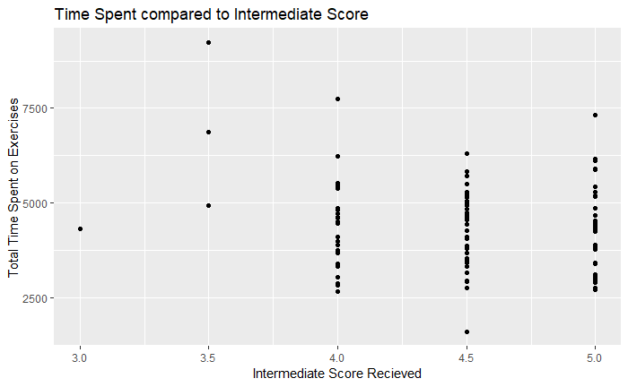

```r
myPlot <- ggplot(data = combined, aes(x = midScore, y = total_time))
myPlot + geom_point() +
  xlab("Intermediate Score Recieved") +
  ylab("Total Time Spent on Exercises") +
  ggtitle("Time Spent compared to Intermediate Score")
```

```r
cor(combined$midScore, combined$total_time)
```

```
[1] -0.1382861
```

# What Further Steps did I take?

Since what what I hypothesized finished with little correlation, I moved forward and correlated all other variables and decided to work off the **two best correlated** variables from my data set.

The following chunck shows the correlation values of each pair of variables.

```r
cor(combined$mouse_click_left, combined$midScore)
```

```
[1] 0.0397142
```

```r
cor(combined$mouse_click_left, combined$total_time)
```

```
[1] 0.4290383
```

```r
cor(combined$mouse_click_left, combined$mouse_click_right)
```

```
[1] 0.4155293
```

```r
cor(combined$mouse_click_left, combined$mouse_movement)
```

```
[1] 0.5159297
```

```r
cor(combined$midScore, combined$total_time)
```

```
[1] -0.1382861
```

```r
cor(combined$midScore, combined$mouse_click_right)
```

```
[1] 0.01253671
```

```r
cor(combined$midScore, combined$mouse_movement)
```

```
[1] 0.1751752
```

```r
cor(combined$mouse_click_right, combined$mouse_movement)
```

```
[1] 0.2614481
```

Looking at all the values, I identified that the connection between the amount of left clicks and the mouse movement yeilds the correlation value that is closes to either **1** or **-1**.

The following graph is one that compares the amount of left clicks of the mouse to the mouse movement.

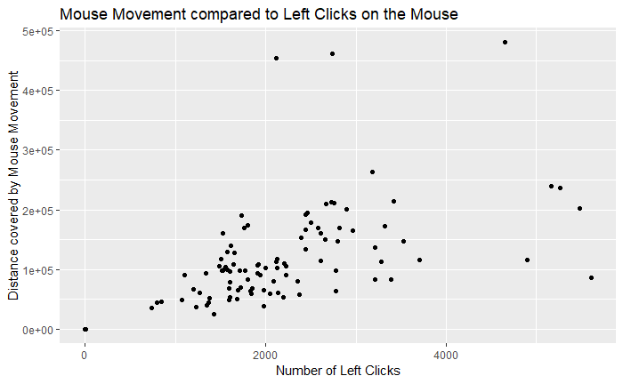

```r
myPlot <- ggplot(data = combined, aes(x = mouse_click_left, y = mouse_movement))
myPlot + geom_point() +
  xlab("Number of Left Clicks") +
  ylab("Distance covered by Mouse Movement")+
  ggtitle("Mouse Movement compared to Left Clicks on the Mouse")
```

There are a few outliers that evident. Using *boxplots*, I identified the outlier points, and removed them from the fit.

The following chunck includes the plotting and removing of outliers.

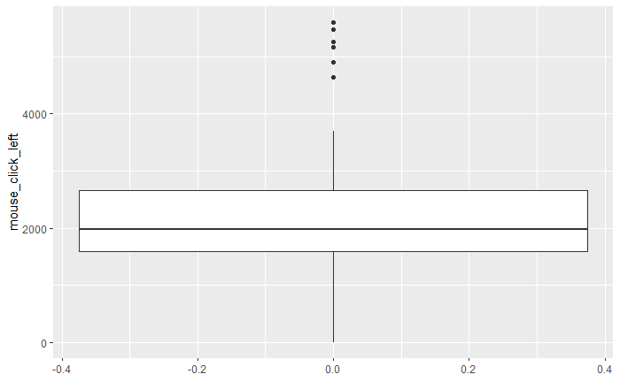

```r
ggplot(combined) + geom_boxplot(aes(y=mouse_click_left))
```

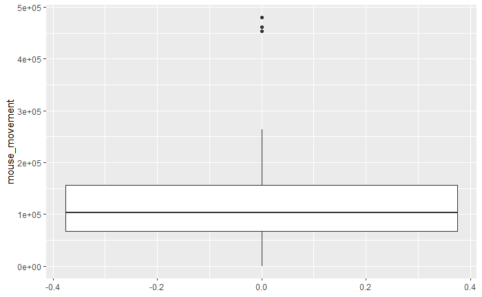

```r
ggplot(combined) + geom_boxplot(aes(y=mouse_movement))
```

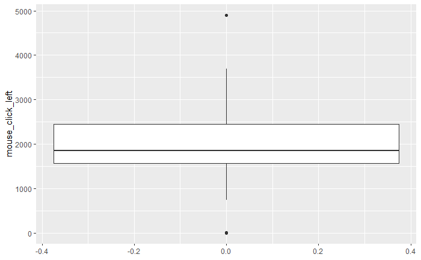

```r
combined2 <- combined[-c(29, 20, 47, 3, 89, 74, 32, 44, 81, 97, 76, 10),]
ggplot(combined2) + geom_boxplot(aes(y=mouse_click_left))
```

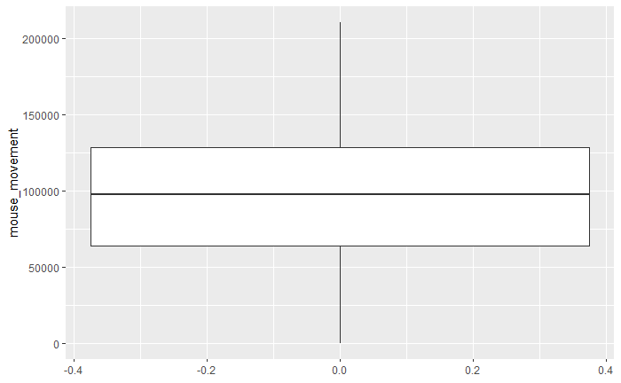

```r
ggplot(combined2) + geom_boxplot(aes(y=mouse_movement))
```

```r
cor(combined2$mouse_click_left, combined2$mouse_movement)
```

```
[1] 0.5403059
```

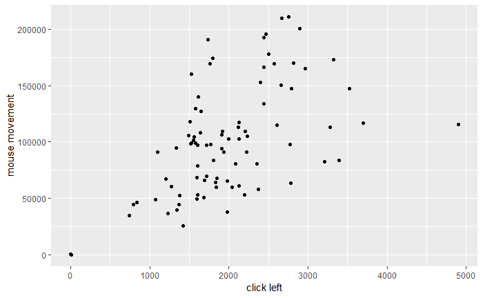

```r
myPlot <- ggplot(data = combined2, aes(x = mouse_click_left, y = mouse_movement))
myPlot + geom_point() +
  xlab("click left") +
  ylab("mouse movement")
```

Through the removal of outliers, I found that the correlation value has increased. With the increase of correlation, the accuracy of the model also changes.

Using the model of mouse movement compared to the amount of left clicks, I continued to create a linear model to **correlate** the two values.

The following chunck shows the building of the linear model.

```r
linModel <- lm(mouse_movement ~ mouse_click_left, data = combined2)
summary(linModel)
```

```
Call:
lm(formula = mouse_movement ~ mouse_click_left, data = combined2)

Residuals:
   Min     1Q Median     3Q    Max
-85780 -32524  -4261  21045  98059

Coefficients:
                  Estimate Std. Error t value Pr(>|t|)
(Intercept)      32761.133  12387.059   2.645  0.00973 **
mouse_click_left    34.407      5.812   5.920 6.61e-08 ***
---
Signif. codes:  0 ‘***’ 0.001 ‘**’ 0.01 ‘*’ 0.05 ‘.’ 0.1 ‘ ’ 1

Residual standard error: 41160 on 85 degrees of freedom
Multiple R-squared:  0.2919,    Adjusted R-squared:  0.2836
F-statistic: 35.04 on 1 and 85 DF,  p-value: 6.609e-08
```

Through comparing the **mouse movement** and the **left clicks of the mouse**, a linear model is created and graphable line is constructed. Furthermore, by summarazing the information, I found that the data had a low p-value which helped support the accuracy of the model. The resuidual median, however is quite far from zero and discourage the accuracy of the model.

The following graph shows the linear model compared to the actual data.

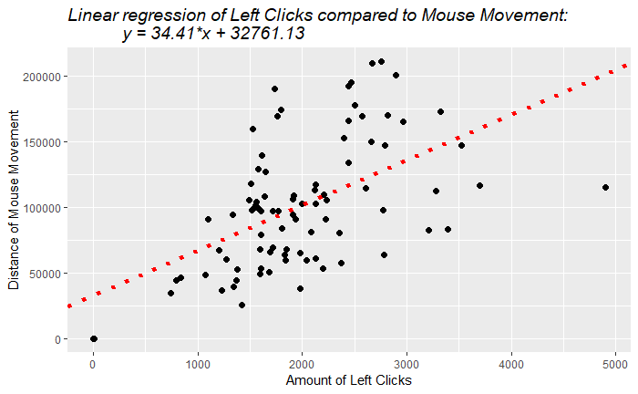

```r
# Plotting the line from: Linear Regression Tutorial
eq = paste0("Linear regression of Left Clicks compared to Mouse Movement:
            y = ", round(linModel$coefficients[2],2),
            "*x + ", round(linModel$coefficients[1],2))
MyPlot <- ggplot(data = combined2, aes(x = mouse_click_left, y = mouse_movement))
MyPlot + geom_point(size = 2) +
  xlab("Amount of Left Clicks") +
  ylab("Distance of Mouse Movement") +
  # add an arbitrary line with slope and intercept
  geom_abline(intercept = linModel$coefficients[1], # extract first coefficient from model
              slope = linModel$coefficients[2], # ditto
              linetype = "dotted",
              color = "red",
              size = 1.5) +
  ggtitle(eq) +
  theme(plot.title = element_text(color="black", size=14, face="italic"))
```

Using the calculated linear model, predictions could be made and used to examplify the accuracy of such a model. I picked 5 values spaced down the model and tested it using the equation from the model.

The following chunck shows the model’s predictions using test values.

```r
# creat test values for predictions
testValues <- data.frame(mouse_click_left = c(1000,1500,2000,2500,3000))
#testing values using the linear model
predict(linModel, testValues)
```

```
        1         2         3         4         5
 67167.95  84371.36 101574.77 118778.17 135981.58
```

### While the model may not be completely accurate because of its large residual mediam, the model does well to predict a value that lies well inside the two extreme bounds seen in the data graphs. This process helped me disprove my hypothesis and show how another pair of variables yeilded a higher correlation than what I believed would.

*~ You have reached the end of this document.~*